# **Malaria Detection**

## **Problem Definition**

**The context:** Why is this problem important to solve?

- Malaria is a life-threatening disease that affects nearly half of the world's population. Traditional diagnosis involves manual inspection, which is time-consuming, labor-intensive, and prone to human error. An automated, accurate, and scalable system for malaria detection can significantly enhance early diagnosis, improve treatment outcomes, and reduce mortality — especially in regions with limited access to skilled healthcare professionals.

**The objectives:** What is the intended goal?

- The goal is to build an efficient computer vision model using deep learning techniques that can automatically classify red blood cell images as either:
  - Parasitized (infected with malaria)
  - Uninfected (healthy or non-malaria-affected) This model should assist in early and reliable detection of malaria, reducing dependency on manual microscopic analysis.

**The key questions:** What are the key questions that need to be answered?

- Can we reliably distinguish between parasitized and uninfected cells using image data alone?
- What deep learning architecture yields the best performance in terms of accuracy, precision, recall, and F1-score?
- How well does the model generalize to unseen data (i.e., is it robust against overfitting)?
- What preprocessing or augmentation techniques are needed to improve model performance?

**The problem formulation:** What is it that we are trying to solve using data science?

- This is a binary image classification problem where the task is to:
  - Input: An RGB image of a red blood cell (32x32x3)
  - Output: A class label — either Parasitized or Uninfected

Using labeled image data, we aim to train a Convolutional Neural Network (CNN) that can learn to detect malaria-related patterns in red blood cells, and automatically classify whether or not the cell is infected. This falls under the domain of supervised learning in computer vision, with a focus on healthcare diagnostics.

## **Data Description**

**Parasitized:** The parasitized cells contain the Plasmodium parasite which causes malaria  
**Uninfected:** The uninfected cells are free of the Plasmodium parasites

### **Mount the Drive**

```python
from google.colab import drive
drive.mount('/content/drive')
```

### **Loading libraries**

```python
# to suppress warnings
import warnings
warnings.filterwarnings('ignore')
```

```python
import numpy as np
import pandas as pd
import matplotlib.pyplot as plt


# For loading unzipping an loading image data
import os
import zipfile
import glob
from tensorflow.keras.preprocessing.image import load_img


# For Data Visualization
import cv2
import seaborn as sns
```

### **Let us load the data**

**Note:**

- You must download the dataset from the link provided on Olympus and upload the same to your Google Drive. Then unzip the folder.

```python
# import zipfile
# import os

# zip_path = "/content/drive/MyDrive/Great Learning x MIT/Deep Learning/Case Studies/Project - Malaria Detection/Cell Images.zip"
# extract_path = "/content/drive/MyDrive/Great Learning x MIT/Deep Learning/Case Studies/Project - Malaria Detection/"

# with zipfile.ZipFile(zip_path, 'r') as zip_ref:
#     zip_ref.extractall(extract_path)

# print("Unzipping Complete!")
```

The extracted folder has different folders for train and test data will contain the different sizes of images for parasitized and uninfected cells within the respective folder name.

The size of all images must be the same and should be converted to 4D arrays so that they can be used as an input for the convolutional neural network. Also, we need to create the labels for both types of images to be able to train and test the model.

Let's do the same for the training data first and then we will use the same code for the test data as well.

```python
# Loading the data
import PIL

# Defining a function that loads PNG images from a folder and converts them to a NumPy array.
def load_png_data(folder_path, target_size = (32,32)):  #(128,128) balances detail vs. computational cost
    image_paths = glob.glob(os.path.join(folder_path, "*.png"))  # Get all PNG file paths
    images = []  # Initialize an empty list to store images

    for img_path in image_paths:
      try:
        image = load_img(img_path, target_size=target_size)  # Load and resize image, also returns 3D array for an image (height, width, RGB)
        images.append(np.array(image, dtype=np.uint8))  # Convert image to NumPy array before appending
      except PIL.UnidentifiedImageError:
            print(f"Skipping file: {img_path} - Could not be opened as an image.")

    return np.stack(images)  # Convert list to NumPy array and return
```

```python
train_parasitized = load_png_data('/content/drive/MyDrive/Great Learning x MIT/Deep Learning/Case Studies/Project - Malaria Detection/cell_images/train/parasitized')
print('Loading of train parasitized is done!')
```

```
Loading of train parasitized is done!
```

```python
train_uninfected = load_png_data('/content/drive/MyDrive/Great Learning x MIT/Deep Learning/Case Studies/Project - Malaria Detection/cell_images/train/uninfected')
print('Loading of train uninfected is done!')
```

```
Loading of train uninfected is done!
```

```python
test_parasitized = load_png_data('/content/drive/MyDrive/Great Learning x MIT/Deep Learning/Case Studies/Project - Malaria Detection/cell_images/test/parasitized')
print('Loading of test parasitized is done!')
```

```
Loading of test parasitized is done!
```

```python
test_uninfected = load_png_data('/content/drive/MyDrive/Great Learning x MIT/Deep Learning/Case Studies/Project - Malaria Detection/cell_images/test/uninfected')
print('Loading of test uninfected is done!')
```

```
Skipping file: /content/drive/MyDrive/Great Learning x MIT/Deep Learning/Case Studies/Project - Malaria Detection/cell_images/test/uninfected/C58P19thinF_IMG_20150802_121847_cell_45.png - Could not be opened as an image.
Loading of test uninfected is done!
```

```python
# Labeling and shuffling train data

# Use 1 for parasitized, 0 for uninfected
labels_parasitized_train = [1] * len(train_parasitized)     # Parasitized
labels_uninfected_train = [0] * len(train_uninfected)       # Uninfected

# Merge images and labels
X_train = np.concatenate([train_parasitized, train_uninfected], axis=0)
y_train = np.concatenate([labels_parasitized_train, labels_uninfected_train], axis=0)

# Shuffle the dataset
from sklearn.utils import shuffle
X_train, y_train = shuffle(X_train, y_train, random_state=42)


# Labeling and shuffling test data

# Use 1 for parasitized, 0 for uninfected
labels_parasitized_test = [1] * len(test_parasitized)     # Infected
labels_uninfected_test = [0] * len(test_uninfected)       # Uninfected

# Merge images and labels
X_test = np.concatenate([test_parasitized, test_uninfected], axis=0)
y_test = np.concatenate([labels_parasitized_test, labels_uninfected_test], axis=0)

# Shuffle the dataset
from sklearn.utils import shuffle
X_test, y_test = shuffle(X_test, y_test, random_state=42)
```

### **Check the shape of train and test images**

```python
print('Shape of image arrays:\n')

print('Shape of training images:', X_train.shape)
print('Shape of testing images:', X_test.shape)


# print('Shape of training data of parasitized:', train_parasitized.shape)
# print('Shape of training data of uninfected:', train_uninfected.shape)
# print('Shape of testing data of parasitized:', test_parasitized.shape)
# print('Shape of testing data of uninfected:', test_uninfected.shape)
```

```
Shape of image arrays:

Shape of training images: (24971, 32, 32, 3)
Shape of testing images: (2599, 32, 32, 3)
```

### **Check the shape of train and test labels**

```python
print('Shape of label arrays:\n')

print('Shape of training labels:', y_train.shape)
print('Shape of testing labels:', y_test.shape)

# print('Shape of training data of parasitized:', train_parasitized_labels.shape)
# print('Shape of training data of uninfected:', train_uninfected_labels.shape)
# print('Shape of testing data of parasitized:', test_parasitized_labels.shape)
# print('Shape of testing data of uninfected:', test_uninfected_labels.shape)
```

```
Shape of label arrays:

Shape of training labels: (24971,)
Shape of testing labels: (2599,)
```

#### **Observations and insights:**

- The image arrays are 4D, with each image having a size of 32x32 pixels and 3 color channels (RGB).
- There are 24971 images in training data in total. The label count is also the same.
- There are 2599 test images in total.

### **Check the minimum and maximum range of pixel values for train and test images**

```python
print("Training images pixel values - Min:", X_train.min(), "Max:", X_train.max())
print("Testing images pixel values - Min:", X_test.min(), "Max:", X_test.max())

# print("Train Parasitized - Min:", train_parasitized.min(), "Max:", train_parasitized.max())
# print("Train Uninfected - Min:", train_uninfected.min(), "Max:", train_uninfected.max())
# print("Test Parasitized - Min:", test_parasitized.min(), "Max:", test_parasitized.max())
# print("Test Uninfected - Min:", test_uninfected.max(), "Max:", test_uninfected.max())
```

```
Training images pixel values - Min: 0 Max: 255
Testing images pixel values - Min: 0 Max: 255
```

#### **Observations and insights:**

- The pixel values are within the range of 0 to 255. These pixel values are in uint8 format, and they are normalized to the range of [0,1] for CNN input.

### **Count the number of values in both uninfected and parasitized**

```python
pd.Series(y_train).value_counts()
```

|  | count |
| --- | --- |
| 1 | 12595 |
| 0 | 12376 |

**dtype:** int64

### **Normalize the images**

```python
X_train_norm = X_train / 255.0  #Dividing by the pixel value to normalize into [0,1] range
X_test_norm = X_test / 255.0
```

#### **Observations and insights:**

- The training label data consists of 12,595 parasitized images and 12,376 uninfected images, indicating a balanced dataset. The training and testing data is normalized by dividing by 255.

### **Plot to check if the data is balanced**

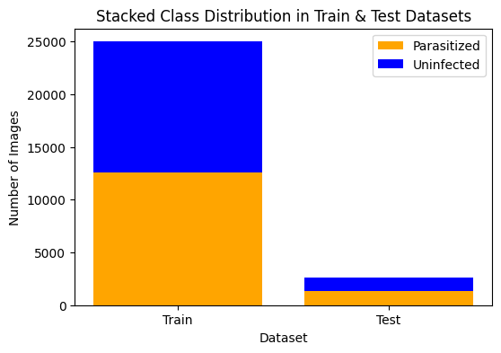

```python
# Count occurrences in each set
train_parasitized_count = np.sum(y_train == 1)
train_uninfected_count = np.sum(y_train == 0)
test_parasitized_count = np.sum(y_test == 1)
test_uninfected_count = np.sum(y_test == 0)

# Prepare data for stacked bar chart
parasitized_counts = [train_parasitized_count, test_parasitized_count]
uninfected_counts = [train_uninfected_count, test_uninfected_count]

# Labels and positions
labels = ['Train', 'Test']
x = np.arange(len(labels))

# Create stacked bar plot
plt.figure(figsize=(6, 4))
plt.bar(x, parasitized_counts, label='Parasitized', color='orange')
plt.bar(x, uninfected_counts, bottom=parasitized_counts, label='Uninfected', color='blue')

# Add labels
plt.xticks(x, labels)
plt.xlabel("Dataset")
plt.ylabel("Number of Images")
plt.title("Stacked Class Distribution in Train & Test Datasets")
plt.legend()

# Show plot
plt.show()
```

#### **Observations and insights:**

- The training dataset is approximately 10 times larger than the test dataset. However, the class distribution in both datasets appears to be balanced, with roughly equal proportions of each class.

### **Data Exploration**

Let's visualize the images from the train data

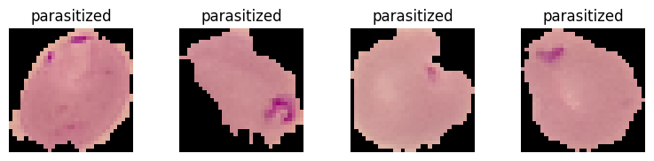

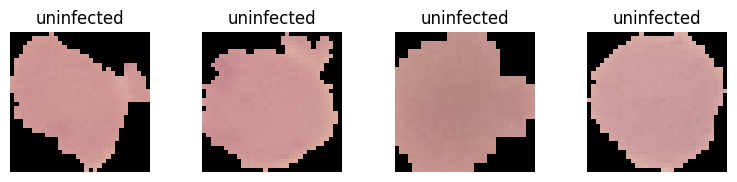

```python
# Declaring the number of rows
rows = 2
# Declaring the number of columns
cols = 5
# Declaring the figure size
fig = plt.figure(figsize = (12, 4))

# Calling the images to the figure for parasitized images
for i in range(4):
    ax = fig.add_subplot(rows, cols, i + 1)  # Create a subplot within the figure
    ax.imshow(train_parasitized[i])  # Display the image
    ax.set_title('parasitized')  # Set the title
    ax.axis("off")  # Hide axes

plt.show()

# Declaring the figure size for new images
fig = plt.figure(figsize = (12,4))
# Calling the images to the figure for uninfected images
for i in range(4):
    ax = fig.add_subplot(rows, cols, i + 1)  # Create a subplot within the figure
    ax.imshow(train_uninfected[i])  # Display the image
    ax.set_title('uninfected')  # Set the title
    ax.axis("off")  # Hide axes

# Display the plot
plt.show()
```

#### **Observations and insights:**

- The parasitized cells often have distinct pink or reddish spots, while the uninfected cells have a more uniform color. Classification can potentially be based on the presence of these differently colored regions.

### **Visualize the images with subplot(6, 6) and figsize = (12, 12)**

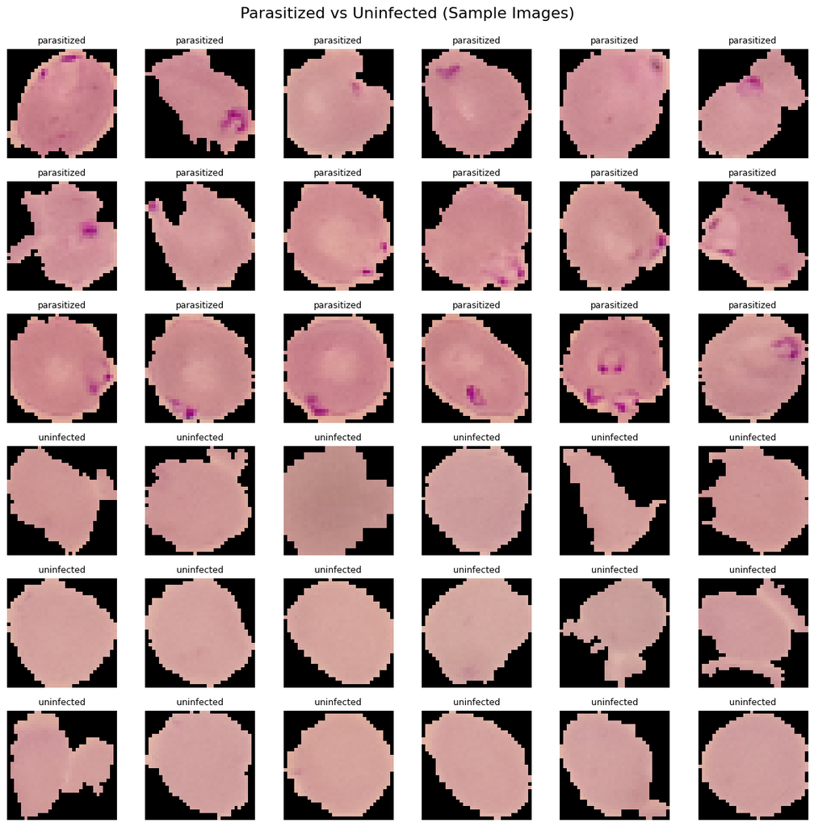

```python
# Select 18 images from each class
n = 18
images = list(train_parasitized[:n]) + list(train_uninfected[:n])
labels = ['parasitized'] * n + ['uninfected'] * n

# # Shuffle them together to mix classes visually
# from sklearn.utils import shuffle
# images, labels = shuffle(images, labels, random_state=42)

# Set up subplots
fig, axes = plt.subplots(6, 6, figsize=(12, 12))
fig.suptitle('Parasitized vs Uninfected (Sample Images)', fontsize=16)

# Flatten axes for easy iteration
axes = axes.flatten()

# Loop through and plot
for i in range(36):
    axes[i].imshow(images[i])
    axes[i].set_title(labels[i], fontsize=9)
    axes[i].axis('off')



plt.tight_layout()
plt.subplots_adjust(top=0.93)  # Give space for suptitle
plt.show()
```

#### **Observations and insights:**

- Cells exhibit variations in shape and a light pink base color. Parasitized cells show greater color variation, often concentrated in one or more distinct spots. Additionally, a cell wall and a darker central area are sometimes visible. The colors across cells can be quite similar, suggesting that higher contrast might be beneficial for differentiating between cell types.

### **Plotting the mean images for parasitized and uninfected**

```python
# Calculating the mean for the images
# Filter parasitized and uninfected from the shuffled data
X_train = X_train.astype(np.float32)  # in case it's still uint8

X_train_parasitized_images = X_train[y_train == 1]
X_train_uninfected_images = X_train[y_train == 0]

# Compute the mean image for each group
X_train_mean_parasitized = np.mean(X_train_parasitized_images, axis=0)
X_train_mean_uninfected = np.mean(X_train_uninfected_images, axis=0)

# Compute global mean image from ALL training images
mean_image = np.mean(X_train, axis=0)

# Subtract mean image from both train and test
X_train_centered = X_train - mean_image
X_test_centered = X_test - mean_image
```

**Mean image for parasitized**

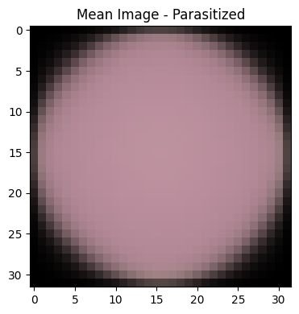

```python
# Plotting mean image for parasitized
plt.figure(figsize=(4,4))

plt.imshow(X_train_mean_parasitized.astype(np.uint8))
plt.title("Mean Image - Parasitized")

plt.tight_layout()
plt.show()
```

**Mean image for uninfected**

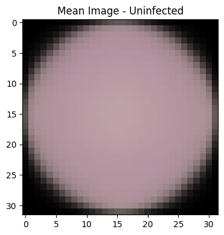

```python
# Plotting mean image for parasitized
plt.figure(figsize=(4,4))

plt.imshow(X_train_mean_uninfected.astype(np.uint8))
plt.title("Mean Image - Uninfected")

plt.tight_layout()
plt.show()
```

### **Converting RGB to HSV of Images using OpenCV**

### **Converting the train data**

```
WARNING:matplotlib.image:Clipping input data to the valid range for imshow with RGB data ([0..1] for floats or [0..255] for integers). Got range [0.0..318.75].
```

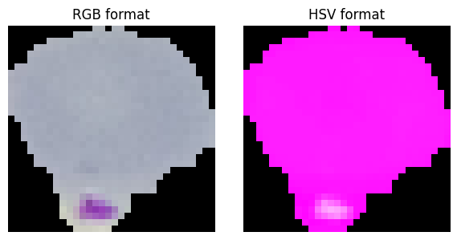

```python
# Function to convert an RGB format to HSV format

def convert_rgb_to_hsv(image_set):
    hsv_images = []  # HSV (Hue, Saturation, Value) color space is allows better image processing for color-based segmentation

    for img in image_set:
        hsv = cv2.cvtColor(img, cv2.COLOR_RGB2HSV)   #Using OpenCV to convert RGB to HSV
        hsv_images.append(hsv)

    return np.array(hsv_images)

X_train_hsv = convert_rgb_to_hsv(X_train)
X_train_hsv.shape


# Displaying RGB and HSV images side by side

fig, ax = plt.subplots(1, 2, figsize=(6, 3))
ax[0].imshow(X_train[0].astype(np.uint8))
ax[0].set_title("RGB format")
ax[0].axis('off')
ax[1].imshow(X_train_hsv[0])
ax[1].set_title("HSV format")
ax[1].axis('off')
plt.tight_layout()
plt.show()
```

### **Converting the test data**

```python
X_test_hsv = convert_rgb_to_hsv(X_test)
X_test_hsv.shape
```

```
(2599, 32, 32, 3)
```

#### **Observations and insights:####**

- The difference between the RGB image and HSV image is significantly different. The conversion appear to make images more distinctive from each other. This may improve the model training and image classification more compared to mean images.

### **Processing Images using Gaussian Blurring**

### **Gaussian Blurring on train data**

```
WARNING:matplotlib.image:Clipping input data to the valid range for imshow with RGB data ([0..1] for floats or [0..255] for integers). Got range [0.0..318.75].
```

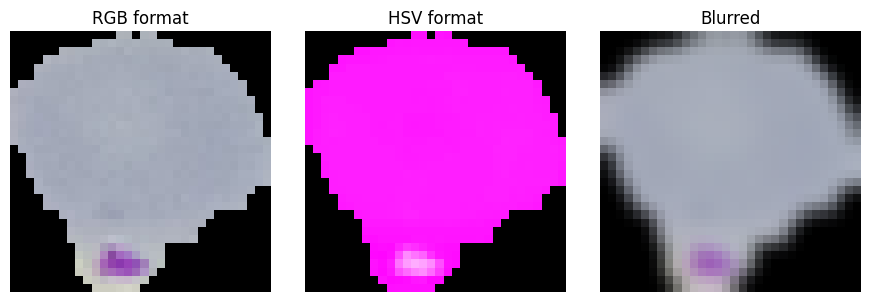

```python
# Gaussian blurring helps reduce image noise and detail to improve model performance in some cases
# e.g. reducing overfitting or highlighting larger patterns

def apply_gaussian_blur(image_set, kernel_size=(5, 5)):
    blurred_images = []
    for img in image_set:
        blurred = cv2.GaussianBlur(img, kernel_size, 0) # Apply Gaussian blur to each image, standard deviation calculated automatically
        blurred_images.append(blurred)
    return np.array(blurred_images)

# applying to the HSV format training data
X_train_blurred = apply_gaussian_blur(X_train_norm)


# Displaying RGB, HSV and blurred images side by side

fig, ax = plt.subplots(1, 3, figsize=(9, 3))
ax[0].imshow(X_train[0].astype(np.uint8))
ax[0].set_title("RGB format")
ax[0].axis('off')
ax[1].imshow(X_train_hsv[0])
ax[1].set_title("HSV format")
ax[1].axis('off')
ax[2].imshow(X_train_blurred[0])
ax[2].set_title("Blurred")
ax[2].axis('off')
plt.tight_layout()
plt.show()
```

### **Gaussian Blurring on test data**

```python
# applying to the HSV format testing data
X_test_blurred = apply_gaussian_blur(X_test_hsv)
```

#### **Observations and insights:

**Think About It:** Would blurring help us for this problem statement in any way? What else can we try?

- Blurring can reduce fine detail, which may be important for distinguishing between parasitized and uninfected cells. It might also decrease recall, potentially leading to parasitized cells being misclassified, which could result in patients not receiving necessary treatment.
- Augmentation
- Bluring not all bot a random bunch

## **Model Building**

### **Base Model**

**Note:** The Base Model has been fully built and evaluated with all outputs shown to give an idea about the process of the creation and evaluation of the performance of a CNN architecture. A similar process can be followed in iterating to build better-performing CNN architectures.

### **Importing the required libraries for building and training our Model**

```python
# For Model Building
import tensorflow as tf
import keras
# from sklearn.model_selection import train_test_split


from tensorflow.keras.models import Sequential, Model # Sequential API for sequential model
from tensorflow.keras.models import load_model
from tensorflow.keras.layers import Dense, Dropout, Flatten # Importing different layers
from tensorflow.keras.layers import Conv2D, MaxPooling2D, BatchNormalization, Activation, Input, LeakyReLU, Activation
from tensorflow.keras.utils import to_categorical # To perform one-hot encoding
from tensorflow.keras.optimizers import RMSprop, Adam, SGD # Optimizers for optimizing the model
from tensorflow.keras.callbacks import EarlyStopping  # Regularization method to prevent the overfitting
from tensorflow.keras.callbacks import ModelCheckpoint
from tensorflow.keras import losses, optimizers
from tensorflow.keras.metrics import Recall, Precision
from tensorflow.keras.preprocessing.image import ImageDataGenerator

# For Model Evaluation
from sklearn.metrics import classification_report
from sklearn.metrics import confusion_matrix

#from google.colab.patches import cv2_imshow
```

#### **One Hot Encoding the train and test labels**

```python
#One-hot encode the target variable
y_train_encoded = to_categorical(y_train)
y_test_encoded = to_categorical(y_test)
```

### **Building the model**

```python
#Clearing previous model's history from the Keras backend
from tensorflow.keras import backend
backend.clear_session()

#Fixing the seed for random number generators so that we can ensure we receive the same output everytime
np.random.seed(42)
import random
random.seed(42)
tf.random.set_seed(42)
```

```python
def ann_model_0():
    model_ann = Sequential()

    # Flatten the input image
    model_ann.add(Flatten(input_shape=(32, 32, 3)))

    # First dense hidden layer
    model_ann.add(Dense(128))
    model_ann.add(LeakyReLU(alpha=0.1))

    # Second dense hidden layer
    model_ann.add(Dense(64))
    model_ann.add(LeakyReLU(alpha=0.1))
    model_ann.add(Dropout(0.3))

    # Output layer
    model_ann.add(Dense(2, activation='softmax'))

    # Compile the model
    opt = Adam(learning_rate=0.001)
    model_ann.compile(optimizer=opt,
                  loss='categorical_crossentropy',
                  metrics=['accuracy', Precision(name='precision'), Recall(name='recall')])

    return model_ann
```

### **Compiling the model**

```python
#Print the summary of the model
model_ann=ann_model_0()
model_ann.summary()
```

```
Model: "sequential"
```

```
┏━━━━━━━━━━━━━━━━━━━━━━━━━━━━━━━━━┳━━━━━━━━━━━━━━━━━━━━━━━━┳━━━━━━━━━━━━━━━┓
┃ Layer (type)                    ┃ Output Shape           ┃       Param # ┃
┡━━━━━━━━━━━━━━━━━━━━━━━━━━━━━━━━━╇━━━━━━━━━━━━━━━━━━━━━━━━╇━━━━━━━━━━━━━━━┩
│ flatten (Flatten)               │ (None, 3072)           │             0 │
├─────────────────────────────────┼────────────────────────┼───────────────┤
│ dense (Dense)                   │ (None, 128)            │       393,344 │
├─────────────────────────────────┼────────────────────────┼───────────────┤
│ leaky_re_lu (LeakyReLU)         │ (None, 128)            │             0 │
├─────────────────────────────────┼────────────────────────┼───────────────┤
│ dense_1 (Dense)                 │ (None, 64)             │         8,256 │
├─────────────────────────────────┼────────────────────────┼───────────────┤
│ leaky_re_lu_1 (LeakyReLU)       │ (None, 64)             │             0 │
├─────────────────────────────────┼────────────────────────┼───────────────┤
│ dropout (Dropout)               │ (None, 64)             │             0 │
├─────────────────────────────────┼────────────────────────┼───────────────┤
│ dense_2 (Dense)                 │ (None, 2)              │           130 │
└─────────────────────────────────┴────────────────────────┴───────────────┘
```

```
 Total params: 401,730 (1.53 MB)
```

```
 Trainable params: 401,730 (1.53 MB)
```

```
 Non-trainable params: 0 (0.00 B)
```

**Using Callbacks**

```python
# Stop training if val_loss doesn't improve for 3 epochs
early_stop = EarlyStopping(monitor='val_loss', patience=3, restore_best_weights=True)

# Save the best model only
checkpoint = ModelCheckpoint('best_model.h5', monitor='val_loss', save_best_only=True)
```

**Fit and train our Model**

```python
# Fit the model on the training data with a validation split of 0.2, batch size = 32, verbose = 1, and epochs = 20
# Store the model building history to use later for visualization
history_ann=model_ann.fit(

    X_train_norm, y_train_encoded,
    epochs = 20,
    validation_split = 0.2,
    callbacks=[early_stop, checkpoint],
    batch_size = 32,
    verbose = 1

    )
```

```
621/625 ━━━━━━━━━━━━━━━━━━━━ 0s 5ms/step - accuracy: 0.5494 - loss: 0.7342 - precision: 0.5494 - recall: 0.5494
```

```
WARNING:absl:You are saving your model as an HDF5 file via `model.save()` or `keras.saving.save_model(model)`. This file format is considered legacy. We recommend using instead the native Keras format, e.g. `model.save('my_model.keras')` or `keras.saving.save_model(model, 'my_model.keras')`.
```

```
625/625 ━━━━━━━━━━━━━━━━━━━━ 5s 6ms/step - accuracy: 0.5496 - loss: 0.7338 - precision: 0.5496 - recall: 0.5496 - val_accuracy: 0.6340 - val_loss: 0.6476 - val_precision: 0.6340 - val_recall: 0.6340
625/625 ━━━━━━━━━━━━━━━━━━━━ 5s 8ms/step - accuracy: 0.6211 - loss: 0.6501 - precision: 0.6211 - recall: 0.6211 - val_accuracy: 0.6260 - val_loss: 0.6488 - val_precision: 0.6260 - val_recall: 0.6260
625/625 ━━━━━━━━━━━━━━━━━━━━ 4s 7ms/step - accuracy: 0.6327 - loss: 0.6390 - precision: 0.6327 - recall: 0.6327 - val_accuracy: 0.5836 - val_loss: 0.7014 - val_precision: 0.5836 - val_recall: 0.5836
625/625 ━━━━━━━━━━━━━━━━━━━━ 0s 5ms/step - accuracy: 0.6553 - loss: 0.6250 - precision: 0.6553 - recall: 0.6553
```

```
WARNING:absl:You are saving your model as an HDF5 file via `model.save()` or `keras.saving.save_model(model)`. This file format is considered legacy. We recommend using instead the native Keras format, e.g. `model.save('my_model.keras')` or `keras.saving.save_model(model, 'my_model.keras')`.
```

```
625/625 ━━━━━━━━━━━━━━━━━━━━ 4s 5ms/step - accuracy: 0.6553 - loss: 0.6250 - precision: 0.6553 - recall: 0.6553 - val_accuracy: 0.6641 - val_loss: 0.6116 - val_precision: 0.6641 - val_recall: 0.6641
624/625 ━━━━━━━━━━━━━━━━━━━━ 0s 6ms/step - accuracy: 0.6699 - loss: 0.6103 - precision: 0.6699 - recall: 0.6699
```

```
WARNING:absl:You are saving your model as an HDF5 file via `model.save()` or `keras.saving.save_model(model)`. This file format is considered legacy. We recommend using instead the native Keras format, e.g. `model.save('my_model.keras')` or `keras.saving.save_model(model, 'my_model.keras')`.
```

```
625/625 ━━━━━━━━━━━━━━━━━━━━ 6s 7ms/step - accuracy: 0.6699 - loss: 0.6103 - precision: 0.6700 - recall: 0.6699 - val_accuracy: 0.6729 - val_loss: 0.5987 - val_precision: 0.6729 - val_recall: 0.6729
625/625 ━━━━━━━━━━━━━━━━━━━━ 4s 6ms/step - accuracy: 0.6773 - loss: 0.6048 - precision: 0.6773 - recall: 0.6773 - val_accuracy: 0.6731 - val_loss: 0.6016 - val_precision: 0.6731 - val_recall: 0.6731
621/625 ━━━━━━━━━━━━━━━━━━━━ 0s 5ms/step - accuracy: 0.6843 - loss: 0.6013 - precision: 0.6843 - recall: 0.6843
```

```
WARNING:absl:You are saving your model as an HDF5 file via `model.save()` or `keras.saving.save_model(model)`. This file format is considered legacy. We recommend using instead the native Keras format, e.g. `model.save('my_model.keras')` or `keras.saving.save_model(model, 'my_model.keras')`.
```

```
625/625 ━━━━━━━━━━━━━━━━━━━━ 5s 5ms/step - accuracy: 0.6843 - loss: 0.6013 - precision: 0.6843 - recall: 0.6843 - val_accuracy: 0.6783 - val_loss: 0.5899 - val_precision: 0.6783 - val_recall: 0.6783
616/625 ━━━━━━━━━━━━━━━━━━━━ 0s 5ms/step - accuracy: 0.6872 - loss: 0.5956 - precision: 0.6872 - recall: 0.6872
```

```
WARNING:absl:You are saving your model as an HDF5 file via `model.save()` or `keras.saving.save_model(model)`. This file format is considered legacy. We recommend using instead the native Keras format, e.g. `model.save('my_model.keras')` or `keras.saving.save_model(model, 'my_model.keras')`.
```

```
625/625 ━━━━━━━━━━━━━━━━━━━━ 3s 5ms/step - accuracy: 0.6873 - loss: 0.5955 - precision: 0.6873 - recall: 0.6873 - val_accuracy: 0.6797 - val_loss: 0.5876 - val_precision: 0.6797 - val_recall: 0.6797
625/625 ━━━━━━━━━━━━━━━━━━━━ 5s 8ms/step - accuracy: 0.6888 - loss: 0.5971 - precision: 0.6888 - recall: 0.6888 - val_accuracy: 0.6699 - val_loss: 0.6042 - val_precision: 0.6699 - val_recall: 0.6699
619/625 ━━━━━━━━━━━━━━━━━━━━ 0s 5ms/step - accuracy: 0.6973 - loss: 0.5891 - precision: 0.6973 - recall: 0.6973
```

```
WARNING:absl:You are saving your model as an HDF5 file via `model.save()` or `keras.saving.save_model(model)`. This file format is considered legacy. We recommend using instead the native Keras format, e.g. `model.save('my_model.keras')` or `keras.saving.save_model(model, 'my_model.keras')`.
```

```
625/625 ━━━━━━━━━━━━━━━━━━━━ 3s 5ms/step - accuracy: 0.6973 - loss: 0.5891 - precision: 0.6973 - recall: 0.6973 - val_accuracy: 0.6785 - val_loss: 0.5868 - val_precision: 0.6785 - val_recall: 0.6785
623/625 ━━━━━━━━━━━━━━━━━━━━ 0s 5ms/step - accuracy: 0.6949 - loss: 0.5887 - precision: 0.6949 - recall: 0.6949
```

```
WARNING:absl:You are saving your model as an HDF5 file via `model.save()` or `keras.saving.save_model(model)`. This file format is considered legacy. We recommend using instead the native Keras format, e.g. `model.save('my_model.keras')` or `keras.saving.save_model(model, 'my_model.keras')`.
```

```
625/625 ━━━━━━━━━━━━━━━━━━━━ 3s 5ms/step - accuracy: 0.6950 - loss: 0.5886 - precision: 0.6950 - recall: 0.6950 - val_accuracy: 0.6795 - val_loss: 0.5854 - val_precision: 0.6795 - val_recall: 0.6795
625/625 ━━━━━━━━━━━━━━━━━━━━ 6s 6ms/step - accuracy: 0.7014 - loss: 0.5851 - precision: 0.7014 - recall: 0.7014 - val_accuracy: 0.6789 - val_loss: 0.5894 - val_precision: 0.6789 - val_recall: 0.6789
615/625 ━━━━━━━━━━━━━━━━━━━━ 0s 5ms/step - accuracy: 0.6951 - loss: 0.5815 - precision: 0.6951 - recall: 0.6951
```

```
WARNING:absl:You are saving your model as an HDF5 file via `model.save()` or `keras.saving.save_model(model)`. This file format is considered legacy. We recommend using instead the native Keras format, e.g. `model.save('my_model.keras')` or `keras.saving.save_model(model, 'my_model.keras')`.
```

```
625/625 ━━━━━━━━━━━━━━━━━━━━ 3s 5ms/step - accuracy: 0.6952 - loss: 0.5814 - precision: 0.6952 - recall: 0.6952 - val_accuracy: 0.6797 - val_loss: 0.5852 - val_precision: 0.6797 - val_recall: 0.6797
625/625 ━━━━━━━━━━━━━━━━━━━━ 3s 5ms/step - accuracy: 0.7028 - loss: 0.5759 - precision: 0.7028 - recall: 0.7028 - val_accuracy: 0.6741 - val_loss: 0.6051 - val_precision: 0.6741 - val_recall: 0.6741
621/625 ━━━━━━━━━━━━━━━━━━━━ 0s 5ms/step - accuracy: 0.7048 - loss: 0.5772 - precision: 0.7048 - recall: 0.7048
```

```
WARNING:absl:You are saving your model as an HDF5 file via `model.save()` or `keras.saving.save_model(model)`. This file format is considered legacy. We recommend using instead the native Keras format, e.g. `model.save('my_model.keras')` or `keras.saving.save_model(model, 'my_model.keras')`.
```

```
625/625 ━━━━━━━━━━━━━━━━━━━━ 4s 6ms/step - accuracy: 0.7048 - loss: 0.5771 - precision: 0.7048 - recall: 0.7048 - val_accuracy: 0.6841 - val_loss: 0.5811 - val_precision: 0.6841 - val_recall: 0.6841
625/625 ━━━━━━━━━━━━━━━━━━━━ 3s 5ms/step - accuracy: 0.7036 - loss: 0.5754 - precision: 0.7036 - recall: 0.7036 - val_accuracy: 0.6871 - val_loss: 0.5824 - val_precision: 0.6871 - val_recall: 0.6871
625/625 ━━━━━━━━━━━━━━━━━━━━ 3s 5ms/step - accuracy: 0.7068 - loss: 0.5712 - precision: 0.7068 - recall: 0.7068 - val_accuracy: 0.6839 - val_loss: 0.5815 - val_precision: 0.6839 - val_recall: 0.6839
619/625 ━━━━━━━━━━━━━━━━━━━━ 0s 6ms/step - accuracy: 0.7086 - loss: 0.5646 - precision: 0.7086 - recall: 0.7086
```

```
WARNING:absl:You are saving your model as an HDF5 file via `model.save()` or `keras.saving.save_model(model)`. This file format is considered legacy. We recommend using instead the native Keras format, e.g. `model.save('my_model.keras')` or `keras.saving.save_model(model, 'my_model.keras')`.
```

```
625/625 ━━━━━━━━━━━━━━━━━━━━ 6s 7ms/step - accuracy: 0.7086 - loss: 0.5646 - precision: 0.7086 - recall: 0.7086 - val_accuracy: 0.6895 - val_loss: 0.5805 - val_precision: 0.6895 - val_recall: 0.6895
625/625 ━━━━━━━━━━━━━━━━━━━━ 4s 5ms/step - accuracy: 0.7064 - loss: 0.5631 - precision: 0.7064 - recall: 0.7064 - val_accuracy: 0.6871 - val_loss: 0.5806 - val_precision: 0.6871 - val_recall: 0.6871
624/625 ━━━━━━━━━━━━━━━━━━━━ 0s 5ms/step - accuracy: 0.7094 - loss: 0.5581 - precision: 0.7094 - recall: 0.7094
```

```
WARNING:absl:You are saving your model as an HDF5 file via `model.save()` or `keras.saving.save_model(model)`. This file format is considered legacy. We recommend using instead the native Keras format, e.g. `model.save('my_model.keras')` or `keras.saving.save_model(model, 'my_model.keras')`.
```

```
625/625 ━━━━━━━━━━━━━━━━━━━━ 5s 5ms/step - accuracy: 0.7094 - loss: 0.5581 - precision: 0.7094 - recall: 0.7094 - val_accuracy: 0.6889 - val_loss: 0.5796 - val_precision: 0.6889 - val_recall: 0.6889
```

### **Save the history object**

```python
import pickle

with open('/content/drive/MyDrive/Great Learning x MIT/Deep Learning/Case Studies/Project - Malaria Detection/history_ann.pkl', 'wb') as file:
    pickle.dump(history_ann.history, file)
```

### **Load the history object**

```python
with open('/content/drive/MyDrive/Great Learning x MIT/Deep Learning/Case Studies/Project - Malaria Detection/history_ann.pkl', 'rb') as file:
    loaded_history = pickle.load(file)
```

```python
#Make predictions on the test set using the second model.
y_pred_ann = model_ann.predict(X_test_norm, verbose=1)
#Convert the probabilities into class labels
y_pred_classes_ann = np.argmax(y_pred_ann, axis = 1)
y_true_classes = np.argmax(y_test_encoded, axis=1)
```

```
82/82 ━━━━━━━━━━━━━━━━━━━━ 0s 2ms/step
```

### **Evaluating the model on test data**

```python
# Generate classification report (includes precision, recall, F1)
print(classification_report(
    y_true_classes, y_pred_classes_ann,
    target_names=['Uninfected', 'Parasitized']
))
```

```
              precision    recall  f1-score   support

  Uninfected       0.64      0.70      0.67      1299
 Parasitized       0.67      0.61      0.64      1300

    accuracy                           0.65      2599
   macro avg       0.66      0.65      0.65      2599
weighted avg       0.66      0.65      0.65      2599
```

**Plotting the confusion matrix**

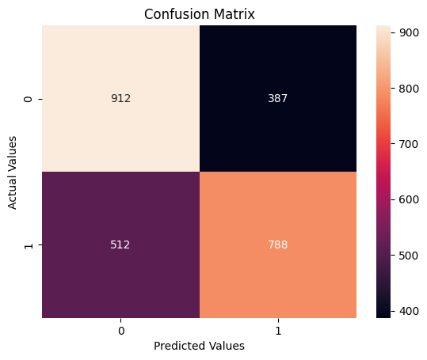

```python
def confus_matrix(y_true, y_pred):
  cm = confusion_matrix(y_true, y_pred)
  sns.heatmap(cm, annot = True, fmt = 'd')
  plt.title('Confusion Matrix')
  plt.ylabel('Actual Values')
  plt.xlabel('Predicted Values')
  plt.show()

confus_matrix(y_test, y_pred_classes_ann)
```

**Plotting the train and validation curves**

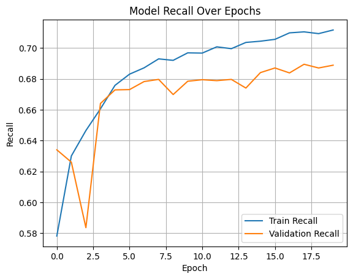

```python
def train_vs_valid_curves(history):
  plt.plot(history.history['recall'], label='Train Recall')
  plt.plot(history.history['val_recall'], label='Validation Recall')
  # plt.plot(history_0.history['precision'])
  # plt.plot(history_0.history['val_precision'])
  plt.title('Model Recall Over Epochs')
  plt.ylabel('Recall')
  plt.xlabel('Epoch')
  plt.legend(loc='lower right')
  plt.grid(True)
  plt.show()

train_vs_valid_curves(history_ann)
```

**Observations:** The model learns fast using the training data initially. The validation recall drops at the beginning and then increases fast but plateuas around 0.68 with some amount of fluctuations, remaining below the training data. Model is overfitting.

Additionally, the overall recall is 0.65. The recall for uninfected is 0.70 and for parasitized is 0.61. The confusion matrix supports the classification report as well. which is insufficient, suggesting that an ANN model is not optimal for this image classification task.

### **Building the model**

```python
#Clearing previous model's history from the Keras backend
from tensorflow.keras import backend
backend.clear_session()

#Fixing the seed for random number generators so that we can ensure we receive the same output everytime
np.random.seed(42)
import random
random.seed(42)
tf.random.set_seed(42)
```

```python
# Defining the function for 1st model:
def cnn_model_0():
  # Initialized a sequential model
  model_0 = Sequential()

  # First Convolutional layer with 16 filters and the kernel size of 3x3. Use the 'same' padding and provide the input shape = (32, 32, 1)
  model_0.add(Conv2D(filters = 16, kernel_size = (3, 3), padding = "same", input_shape = (32, 32, 3)))
  # Add a LeakyRelu layer with the slope equal to 0.1
  model_0.add(LeakyReLU(0.1))

  # Second Convolutional layer with 32 filters and the kernel size of 3x3 with 'same' padding
  model_0.add(Conv2D(filters = 32, kernel_size = (3, 3), padding = "same"))
  # Another LeakyRelu with the slope equal to 0.1
  model_0.add(LeakyReLU(0.1))
  # A max-pooling layer with a pool size of 2x2
  model_0.add(MaxPooling2D(pool_size = (2, 2)))

  # Flatten the output from the previous layer
  model_0.add(Flatten())
  # Add a dense layer with 32 nodes
  model_0.add(Dense(32))
  # Add a LeakyRelu layer with the slope equal to 0.1
  model_0.add(LeakyReLU(0.1))

  # Add the final output layer with nodes equal to the number of classes, i.e., 10 and 'softmax' as the activation function
  model_0.add(Dense(y_train_encoded.shape[1], activation = 'softmax'))

  # Optimizer equal to Adam(learning_rate = 0.001)
  opt= Adam(learning_rate = 0.001)

  # Compile the model with the loss equal to categorical_crossentropy, optimizer and metric equal to 'accuracy'.
  model_0.compile(opt, loss = 'categorical_crossentropy', metrics=['accuracy', Precision(name='precision'), Recall(name='recall')])

  return model_0
```

### **Compiling the model**

```python
#Print the summary of the model
model_0=cnn_model_0()
model_0.summary()
```

```
Model: "sequential"
```

```
┏━━━━━━━━━━━━━━━━━━━━━━━━━━━━━━━━━┳━━━━━━━━━━━━━━━━━━━━━━━━┳━━━━━━━━━━━━━━━┓
┃ Layer (type)                    ┃ Output Shape           ┃       Param # ┃
┡━━━━━━━━━━━━━━━━━━━━━━━━━━━━━━━━━╇━━━━━━━━━━━━━━━━━━━━━━━━╇━━━━━━━━━━━━━━━┩
│ conv2d (Conv2D)                 │ (None, 32, 32, 16)     │           448 │
├─────────────────────────────────┼────────────────────────┼───────────────┤
│ leaky_re_lu (LeakyReLU)         │ (None, 32, 32, 16)     │             0 │
├─────────────────────────────────┼────────────────────────┼───────────────┤
│ conv2d_1 (Conv2D)               │ (None, 32, 32, 32)     │         4,640 │
├─────────────────────────────────┼────────────────────────┼───────────────┤
│ leaky_re_lu_1 (LeakyReLU)       │ (None, 32, 32, 32)     │             0 │
├─────────────────────────────────┼────────────────────────┼───────────────┤
│ max_pooling2d (MaxPooling2D)    │ (None, 16, 16, 32)     │             0 │
├─────────────────────────────────┼────────────────────────┼───────────────┤
│ flatten (Flatten)               │ (None, 8192)           │             0 │
├─────────────────────────────────┼────────────────────────┼───────────────┤
│ dense (Dense)                   │ (None, 32)             │       262,176 │
├─────────────────────────────────┼────────────────────────┼───────────────┤
│ leaky_re_lu_2 (LeakyReLU)       │ (None, 32)             │             0 │
├─────────────────────────────────┼────────────────────────┼───────────────┤
│ dense_1 (Dense)                 │ (None, 2)              │            66 │
└─────────────────────────────────┴────────────────────────┴───────────────┘
```

```
 Total params: 267,330 (1.02 MB)
```

```
 Trainable params: 267,330 (1.02 MB)
```

```
 Non-trainable params: 0 (0.00 B)
```

**Using Callbacks**

```python
# Stop training if val_loss doesn't improve for 3 epochs
early_stop = EarlyStopping(monitor='val_loss', patience=3, restore_best_weights=True)

# Save the best model only
checkpoint = ModelCheckpoint('best_model.h5', monitor='val_loss', save_best_only=True)
```

**Fit and train our Model**

```python
# Fit the model on the training data with a validation split of 0.2, batch size = 32, verbose = 1, and epochs = 20
# Store the model building history to use later for visualization
history_0=model_0.fit(

    X_train_norm, y_train_encoded,
    epochs = 20,
    validation_split = 0.2,
    batch_size = 32,
    callbacks=[early_stop, checkpoint],
    verbose = 1

    )
```

```
623/625 ━━━━━━━━━━━━━━━━━━━━ 0s 39ms/step - accuracy: 0.6419 - loss: 0.6203 - precision: 0.6419 - recall: 0.6419
```

```
WARNING:absl:You are saving your model as an HDF5 file via `model.save()` or `keras.saving.save_model(model)`. This file format is considered legacy. We recommend using instead the native Keras format, e.g. `model.save('my_model.keras')` or `keras.saving.save_model(model, 'my_model.keras')`.
```

```
625/625 ━━━━━━━━━━━━━━━━━━━━ 29s 43ms/step - accuracy: 0.6423 - loss: 0.6199 - precision: 0.6423 - recall: 0.6423 - val_accuracy: 0.8895 - val_loss: 0.3089 - val_precision: 0.8895 - val_recall: 0.8895
624/625 ━━━━━━━━━━━━━━━━━━━━ 0s 36ms/step - accuracy: 0.9158 - loss: 0.2249 - precision: 0.9158 - recall: 0.9158
```

```
WARNING:absl:You are saving your model as an HDF5 file via `model.save()` or `keras.saving.save_model(model)`. This file format is considered legacy. We recommend using instead the native Keras format, e.g. `model.save('my_model.keras')` or `keras.saving.save_model(model, 'my_model.keras')`.
```

```
625/625 ━━━━━━━━━━━━━━━━━━━━ 25s 40ms/step - accuracy: 0.9159 - loss: 0.2248 - precision: 0.9159 - recall: 0.9159 - val_accuracy: 0.9483 - val_loss: 0.1289 - val_precision: 0.9483 - val_recall: 0.9483
623/625 ━━━━━━━━━━━━━━━━━━━━ 0s 37ms/step - accuracy: 0.9535 - loss: 0.1274 - precision: 0.9535 - recall: 0.9535
```

```
WARNING:absl:You are saving your model as an HDF5 file via `model.save()` or `keras.saving.save_model(model)`. This file format is considered legacy. We recommend using instead the native Keras format, e.g. `model.save('my_model.keras')` or `keras.saving.save_model(model, 'my_model.keras')`.
```

```
625/625 ━━━━━━━━━━━━━━━━━━━━ 41s 41ms/step - accuracy: 0.9535 - loss: 0.1273 - precision: 0.9535 - recall: 0.9535 - val_accuracy: 0.9552 - val_loss: 0.1195 - val_precision: 0.9552 - val_recall: 0.9552
625/625 ━━━━━━━━━━━━━━━━━━━━ 25s 40ms/step - accuracy: 0.9654 - loss: 0.1022 - precision: 0.9654 - recall: 0.9654 - val_accuracy: 0.9536 - val_loss: 0.1483 - val_precision: 0.9536 - val_recall: 0.9536
625/625 ━━━━━━━━━━━━━━━━━━━━ 42s 41ms/step - accuracy: 0.9706 - loss: 0.0895 - precision: 0.9706 - recall: 0.9706 - val_accuracy: 0.9582 - val_loss: 0.1336 - val_precision: 0.9582 - val_recall: 0.9582
623/625 ━━━━━━━━━━━━━━━━━━━━ 0s 37ms/step - accuracy: 0.9743 - loss: 0.0795 - precision: 0.9743 - recall: 0.9743
```

```
WARNING:absl:You are saving your model as an HDF5 file via `model.save()` or `keras.saving.save_model(model)`. This file format is considered legacy. We recommend using instead the native Keras format, e.g. `model.save('my_model.keras')` or `keras.saving.save_model(model, 'my_model.keras')`.
```

```
625/625 ━━━━━━━━━━━━━━━━━━━━ 41s 41ms/step - accuracy: 0.9743 - loss: 0.0795 - precision: 0.9743 - recall: 0.9743 - val_accuracy: 0.9644 - val_loss: 0.1133 - val_precision: 0.9644 - val_recall: 0.9644
625/625 ━━━━━━━━━━━━━━━━━━━━ 41s 40ms/step - accuracy: 0.9779 - loss: 0.0634 - precision: 0.9779 - recall: 0.9779 - val_accuracy: 0.9660 - val_loss: 0.1230 - val_precision: 0.9660 - val_recall: 0.9660
624/625 ━━━━━━━━━━━━━━━━━━━━ 0s 39ms/step - accuracy: 0.9818 - loss: 0.0550 - precision: 0.9818 - recall: 0.9818
```

```
WARNING:absl:You are saving your model as an HDF5 file via `model.save()` or `keras.saving.save_model(model)`. This file format is considered legacy. We recommend using instead the native Keras format, e.g. `model.save('my_model.keras')` or `keras.saving.save_model(model, 'my_model.keras')`.
```

```
625/625 ━━━━━━━━━━━━━━━━━━━━ 42s 43ms/step - accuracy: 0.9819 - loss: 0.0550 - precision: 0.9819 - recall: 0.9819 - val_accuracy: 0.9704 - val_loss: 0.1043 - val_precision: 0.9704 - val_recall: 0.9704
625/625 ━━━━━━━━━━━━━━━━━━━━ 40s 40ms/step - accuracy: 0.9834 - loss: 0.0446 - precision: 0.9834 - recall: 0.9834 - val_accuracy: 0.9616 - val_loss: 0.1176 - val_precision: 0.9616 - val_recall: 0.9616
625/625 ━━━━━━━━━━━━━━━━━━━━ 41s 41ms/step - accuracy: 0.9875 - loss: 0.0345 - precision: 0.9875 - recall: 0.9875 - val_accuracy: 0.9664 - val_loss: 0.1143 - val_precision: 0.9664 - val_recall: 0.9664
625/625 ━━━━━━━━━━━━━━━━━━━━ 25s 40ms/step - accuracy: 0.9890 - loss: 0.0314 - precision: 0.9890 - recall: 0.9890 - val_accuracy: 0.9694 - val_loss: 0.1146 - val_precision: 0.9694 - val_recall: 0.9694
```

### **Save the history object**

```python
import pickle

with open('/content/drive/MyDrive/Great Learning x MIT/Deep Learning/Case Studies/Project - Malaria Detection/history_0.pkl', 'wb') as file:
    pickle.dump(history_0.history, file)
```

### **Load the history object**

```python
with open('/content/drive/MyDrive/Great Learning x MIT/Deep Learning/Case Studies/Project - Malaria Detection/history_0.pkl', 'rb') as file:
    loaded_history = pickle.load(file)
```

### **Evaluating the model on test data**

```python
#Make predictions on the test set using the second model.
y_pred_0 = model_0.predict(X_test_norm, verbose=1)
#Convert the probabilities into class labels
y_pred_classes_0 = np.argmax(y_pred_0, axis = 1)
y_true_classes = np.argmax(y_test_encoded, axis=1)
```

```
82/82 ━━━━━━━━━━━━━━━━━━━━ 1s 17ms/step
```

```python
# Generate classification report (includes precision, recall, F1)
print(classification_report(
    y_true_classes, y_pred_classes_0,
    target_names=['Uninfected', 'Parasitized']
))
```

```
              precision    recall  f1-score   support

  Uninfected       0.96      0.98      0.97      1299
 Parasitized       0.98      0.96      0.97      1300

    accuracy                           0.97      2599
   macro avg       0.97      0.97      0.97      2599
weighted avg       0.97      0.97      0.97      2599
```

**Plotting the confusion matrix**

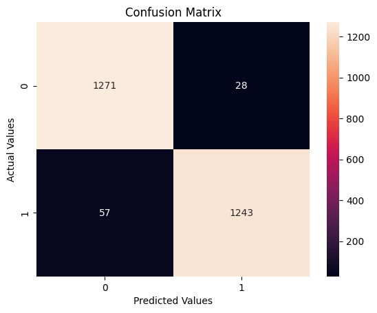

```python
confus_matrix(y_test, y_pred_classes_0)
```

**Plotting the train and validation curves**

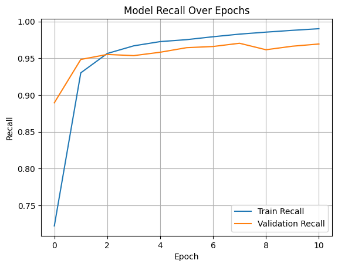

```python
train_vs_valid_curves(history_0)
```

**Observations:**

- The model learns fast ath the 1st epoch. After that the training data is increasing steadily, while validation plateaus below the validation recall. The gap between training and validation recalls is increasing very slowly, so there may be a bit overfitting, but the gap is also so slight that it may also be acceptable. The recall for parasitized is at 0.96. It is a great improvement compared to previous ANN model. However, since this is a critical classification for malaria patients, this should still be improved.

So now let's try to build another model with few more add on layers and try to check if we can try to improve the model. Therefore try to build a model by adding few layers if required and altering the activation functions.

### **Model 1**

#### **Trying to improve the performance of our model by adding new layers**

```python
#Clearing previous model's history from the Keras backend
from tensorflow.keras import backend
backend.clear_session()

#Fixing the seed for random number generators so that we can ensure we receive the same output everytime
np.random.seed(42)
import random
random.seed(42)
tf.random.set_seed(42)
```

### **Building the Model**

```python
# Defining the function for 1st model:
def cnn_model_1():
  # Initialized a sequential model
  model_1 = Sequential()

  # First Convolutional layer with 16 filters and the kernel size of 3x3. Use the 'same' padding and provide the input shape = (32, 32, 1)
  model_1.add(Conv2D(filters = 16, kernel_size = (3, 3), padding = "same", input_shape = (32, 32, 3))) #16 filters detects edges, textures
  # Add a LeakyRelu layer with the slope equal to 0.1
  model_1.add(LeakyReLU(0.1))

  # Second Convolutional layer with 32 filters and the kernel size of 3x3 with 'same' padding
  model_1.add(Conv2D(filters = 32, kernel_size = (3, 3), padding = "same")) #32 filters detects shapes, blobs
  # Another LeakyRelu with the slope equal to 0.1
  model_1.add(LeakyReLU(0.1))
  # A max-pooling layer with a pool size of 2x2
  model_1.add(MaxPooling2D(pool_size = (2, 2)))
  # Dropout that turns off  25% of neurons in a layer
  model_1.add(Dropout(0.25))

  # Third Convolutional layer with 64 filters and the kernel size of 3x3 with 'same' padding
  model_1.add(Conv2D(filters = 64, kernel_size = (3, 3), padding = "same")) #64 filters detects meaningful patterns
  # Another LeakyRelu with the slope equal to 0.1
  model_1.add(LeakyReLU(0.1))
  # A max-pooling layer with a pool size of 2x2
  model_1.add(MaxPooling2D(pool_size = (2, 2)))
  # Dropout that turns off  30% of neurons in a layer
  model_1.add(Dropout(0.30))

  # Flatten the output from the previous layer
  model_1.add(Flatten())
  # Add a dense layer with 64 nodes
  model_1.add(Dense(64))
  # Add a LeakyRelu layer with the slope equal to 0.1
  model_1.add(LeakyReLU(0.1))
  # Dropout that turns off  40% of neurons in a layer
  model_1.add(Dropout(0.40))

  # Add the final output layer with nodes equal to the number of classes, i.e., 10 and 'softmax' as the activation function
  model_1.add(Dense(y_train_encoded.shape[1], activation = 'softmax'))

  # Optimizer equal to Adam(learning_rate = 0.001)
  opt= Adam(learning_rate = 0.001)

  # Compile the model with the loss equal to categorical_crossentropy, optimizer and metric equal to 'accuracy'.
  model_1.compile(opt, loss = 'categorical_crossentropy', metrics=['accuracy', Precision(name='precision'), Recall(name='recall')])

  return model_1
```

### **Compiling the model**

```python
#Print the summary of the model
model_1=cnn_model_1()
model_1.summary()
```

```
Model: "sequential"
```

```
┏━━━━━━━━━━━━━━━━━━━━━━━━━━━━━━━━━┳━━━━━━━━━━━━━━━━━━━━━━━━┳━━━━━━━━━━━━━━━┓
┃ Layer (type)                    ┃ Output Shape           ┃       Param # ┃
┡━━━━━━━━━━━━━━━━━━━━━━━━━━━━━━━━━╇━━━━━━━━━━━━━━━━━━━━━━━━╇━━━━━━━━━━━━━━━┩
│ conv2d (Conv2D)                 │ (None, 32, 32, 16)     │           448 │
├─────────────────────────────────┼────────────────────────┼───────────────┤
│ leaky_re_lu (LeakyReLU)         │ (None, 32, 32, 16)     │             0 │
├─────────────────────────────────┼────────────────────────┼───────────────┤
│ conv2d_1 (Conv2D)               │ (None, 32, 32, 32)     │         4,640 │
├─────────────────────────────────┼────────────────────────┼───────────────┤
│ leaky_re_lu_1 (LeakyReLU)       │ (None, 32, 32, 32)     │             0 │
├─────────────────────────────────┼────────────────────────┼───────────────┤
│ max_pooling2d (MaxPooling2D)    │ (None, 16, 16, 32)     │             0 │
├─────────────────────────────────┼────────────────────────┼───────────────┤
│ dropout (Dropout)               │ (None, 16, 16, 32)     │             0 │
├─────────────────────────────────┼────────────────────────┼───────────────┤
│ conv2d_2 (Conv2D)               │ (None, 16, 16, 64)     │        18,496 │
├─────────────────────────────────┼────────────────────────┼───────────────┤
│ leaky_re_lu_2 (LeakyReLU)       │ (None, 16, 16, 64)     │             0 │
├─────────────────────────────────┼────────────────────────┼───────────────┤
│ max_pooling2d_1 (MaxPooling2D)  │ (None, 8, 8, 64)       │             0 │
├─────────────────────────────────┼────────────────────────┼───────────────┤
│ dropout_1 (Dropout)             │ (None, 8, 8, 64)       │             0 │
├─────────────────────────────────┼────────────────────────┼───────────────┤
│ flatten (Flatten)               │ (None, 4096)           │             0 │
├─────────────────────────────────┼────────────────────────┼───────────────┤
│ dense (Dense)                   │ (None, 64)             │       262,208 │
├─────────────────────────────────┼────────────────────────┼───────────────┤
│ leaky_re_lu_3 (LeakyReLU)       │ (None, 64)             │             0 │
├─────────────────────────────────┼────────────────────────┼───────────────┤
│ dropout_2 (Dropout)             │ (None, 64)             │             0 │
├─────────────────────────────────┼────────────────────────┼───────────────┤
│ dense_1 (Dense)                 │ (None, 2)              │           130 │
└─────────────────────────────────┴────────────────────────┴───────────────┘
```

```
 Total params: 285,922 (1.09 MB)
```

```
 Trainable params: 285,922 (1.09 MB)
```

```
 Non-trainable params: 0 (0.00 B)
```

**Using Callbacks**

```python
# Stop training if val_loss doesn't improve for 3 epochs
early_stop = EarlyStopping(monitor='val_loss', patience=3, restore_best_weights=True)

# Save the best model only
checkpoint = ModelCheckpoint('best_model.h5', monitor='val_loss', save_best_only=True)
```

**Fit and Train the model**

```python
# Fit the model on the training data with a validation split of 0.2, batch size = 32, verbose = 1, and epochs = 20
# Store the model building history to use later for visualization
history_1=model_1.fit(

    X_train_norm, y_train_encoded,
    epochs = 20,
    validation_split = 0.2,
    callbacks=[early_stop, checkpoint],
    batch_size = 32,
    verbose = 1

    )
```

```
624/625 ━━━━━━━━━━━━━━━━━━━━ 0s 57ms/step - accuracy: 0.6617 - loss: 0.5789 - precision: 0.6617 - recall: 0.6617
```

```
WARNING:absl:You are saving your model as an HDF5 file via `model.save()` or `keras.saving.save_model(model)`. This file format is considered legacy. We recommend using instead the native Keras format, e.g. `model.save('my_model.keras')` or `keras.saving.save_model(model, 'my_model.keras')`.
```

```
625/625 ━━━━━━━━━━━━━━━━━━━━ 40s 61ms/step - accuracy: 0.6622 - loss: 0.5783 - precision: 0.6622 - recall: 0.6622 - val_accuracy: 0.9676 - val_loss: 0.0974 - val_precision: 0.9676 - val_recall: 0.9676
624/625 ━━━━━━━━━━━━━━━━━━━━ 0s 73ms/step - accuracy: 0.9664 - loss: 0.1042 - precision: 0.9664 - recall: 0.9664
```

```
WARNING:absl:You are saving your model as an HDF5 file via `model.save()` or `keras.saving.save_model(model)`. This file format is considered legacy. We recommend using instead the native Keras format, e.g. `model.save('my_model.keras')` or `keras.saving.save_model(model, 'my_model.keras')`.
```

```
625/625 ━━━━━━━━━━━━━━━━━━━━ 51s 77ms/step - accuracy: 0.9665 - loss: 0.1042 - precision: 0.9665 - recall: 0.9665 - val_accuracy: 0.9744 - val_loss: 0.0730 - val_precision: 0.9744 - val_recall: 0.9744
624/625 ━━━━━━━━━━━━━━━━━━━━ 0s 56ms/step - accuracy: 0.9751 - loss: 0.0751 - precision: 0.9751 - recall: 0.9751
```

```
WARNING:absl:You are saving your model as an HDF5 file via `model.save()` or `keras.saving.save_model(model)`. This file format is considered legacy. We recommend using instead the native Keras format, e.g. `model.save('my_model.keras')` or `keras.saving.save_model(model, 'my_model.keras')`.
```

```
625/625 ━━━━━━━━━━━━━━━━━━━━ 71s 60ms/step - accuracy: 0.9751 - loss: 0.0751 - precision: 0.9751 - recall: 0.9751 - val_accuracy: 0.9782 - val_loss: 0.0639 - val_precision: 0.9782 - val_recall: 0.9782
624/625 ━━━━━━━━━━━━━━━━━━━━ 0s 57ms/step - accuracy: 0.9761 - loss: 0.0712 - precision: 0.9761 - recall: 0.9761
```

```
WARNING:absl:You are saving your model as an HDF5 file via `model.save()` or `keras.saving.save_model(model)`. This file format is considered legacy. We recommend using instead the native Keras format, e.g. `model.save('my_model.keras')` or `keras.saving.save_model(model, 'my_model.keras')`.
```

```
625/625 ━━━━━━━━━━━━━━━━━━━━ 42s 61ms/step - accuracy: 0.9761 - loss: 0.0712 - precision: 0.9761 - recall: 0.9761 - val_accuracy: 0.9794 - val_loss: 0.0557 - val_precision: 0.9794 - val_recall: 0.9794
624/625 ━━━━━━━━━━━━━━━━━━━━ 0s 59ms/step - accuracy: 0.9762 - loss: 0.0689 - precision: 0.9762 - recall: 0.9762
```

```
WARNING:absl:You are saving your model as an HDF5 file via `model.save()` or `keras.saving.save_model(model)`. This file format is considered legacy. We recommend using instead the native Keras format, e.g. `model.save('my_model.keras')` or `keras.saving.save_model(model, 'my_model.keras')`.
```

```
625/625 ━━━━━━━━━━━━━━━━━━━━ 39s 63ms/step - accuracy: 0.9762 - loss: 0.0689 - precision: 0.9762 - recall: 0.9762 - val_accuracy: 0.9822 - val_loss: 0.0518 - val_precision: 0.9822 - val_recall: 0.9822
625/625 ━━━━━━━━━━━━━━━━━━━━ 39s 60ms/step - accuracy: 0.9784 - loss: 0.0636 - precision: 0.9784 - recall: 0.9784 - val_accuracy: 0.9788 - val_loss: 0.0558 - val_precision: 0.9788 - val_recall: 0.9788
625/625 ━━━━━━━━━━━━━━━━━━━━ 38s 61ms/step - accuracy: 0.9788 - loss: 0.0610 - precision: 0.9788 - recall: 0.9788 - val_accuracy: 0.9754 - val_loss: 0.0636 - val_precision: 0.9754 - val_recall: 0.9754
625/625 ━━━━━━━━━━━━━━━━━━━━ 42s 62ms/step - accuracy: 0.9763 - loss: 0.0690 - precision: 0.9763 - recall: 0.9763 - val_accuracy: 0.9786 - val_loss: 0.0696 - val_precision: 0.9786 - val_recall: 0.9786
```

### **Save the history object**

```python
with open('/content/drive/MyDrive/Great Learning x MIT/Deep Learning/Case Studies/Project - Malaria Detection/history_1.pkl', 'wb') as file:
    pickle.dump(history_1.history, file)
```

### **Load the history object**

```python
with open('/content/drive/MyDrive/Great Learning x MIT/Deep Learning/Case Studies/Project - Malaria Detection/history_1.pkl', 'rb') as file:
    loaded_history = pickle.load(file)
```

### **Evaluating the model**

```python
#Make predictions on the test set using the second model.
y_pred_1 = model_1.predict(X_test_norm, verbose=1)
#Convert the probabilities into class labels
y_pred_classes_1 = np.argmax(y_pred_1, axis = 1)
y_true_classes = np.argmax(y_test_encoded, axis=1)
```

```
82/82 ━━━━━━━━━━━━━━━━━━━━ 1s 15ms/step
```

```python
# Generate classification report (includes precision, recall, F1)
print(classification_report(
    y_true_classes, y_pred_classes_1,
    target_names=['Uninfected', 'Parasitized']
))
```

```
              precision    recall  f1-score   support

  Uninfected       0.99      0.99      0.99      1299
 Parasitized       0.99      0.99      0.99      1300

    accuracy                           0.99      2599
   macro avg       0.99      0.99      0.99      2599
weighted avg       0.99      0.99      0.99      2599
```

**Plotting the confusion matrix**

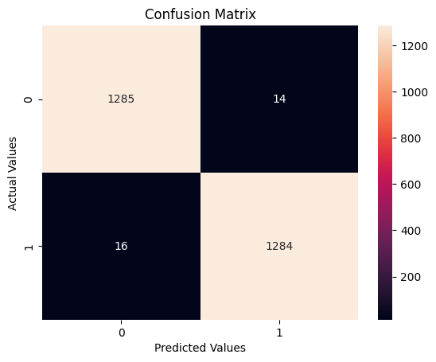

```python
#Ploting the heatmap from the confusion matrix
confus_matrix(y_test, y_pred_classes_1)
```

**Plotting the train and the validation curves**

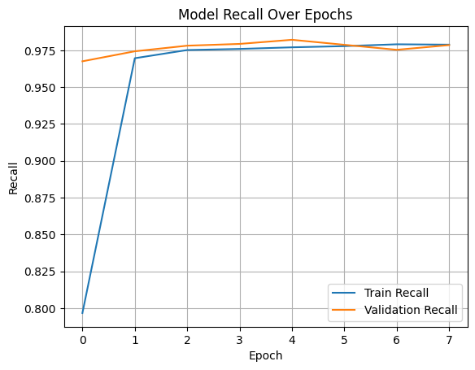

```python
train_vs_valid_curves(history_1)
```

**Observations**:

- Model converges fast, no signs of overfitting or underfitting
- Precision, Recall, and F1-score: all 0.99 for both classes
  - Balanced classifier — it’s not favoring one class over another
  - Great for medical imaging use cases, where recall (sensitivity) is critical

### **Think about it:**

Now let's build a model with LeakyRelu as the activation function

- Can the model performance be improved if we change our activation function to LeakyRelu?
- Can BatchNormalization improve our model?

Let us try to build a model using BatchNormalization and using LeakyRelu as our activation function.

### **Model 2 with Batch Normalization**

```python
#Clearing previous model's history from the Keras backend
from tensorflow.keras import backend
backend.clear_session()

#Fixing the seed for random number generators so that we can ensure we receive the same output everytime
np.random.seed(42)
import random
random.seed(42)
tf.random.set_seed(42)
```

### **Building the Model**

```python
# Defining the function for 1st model:
def cnn_model_2():
  # Initialized a sequential model
  model_2 = Sequential()

  # First Convolutional layer with 16 filters and the kernel size of 3x3. Use the 'same' padding and provide the input shape = (32, 32, 1)
  model_2.add(Conv2D(filters = 16, kernel_size = (3, 3), padding = "same", input_shape = (32, 32, 3))) #16 filters detects edges, textures
  # Add a BatchNormalization layer
  model_2.add(BatchNormalization())
  # Add a LeakyRelu layer with the slope equal to 0.1
  model_2.add(LeakyReLU(0.1)) #LeakyRelu was also used in previous model

  # Second Convolutional layer with 32 filters and the kernel size of 3x3 with 'same' padding
  model_2.add(Conv2D(filters = 32, kernel_size = (3, 3), padding = "same")) #32 filters detects shapes, blobs
  # Add a BatchNormalization layer
  model_2.add(BatchNormalization())
  # Another LeakyRelu with the slope equal to 0.1
  model_2.add(LeakyReLU(0.1))
  # A max-pooling layer with a pool size of 2x2
  model_2.add(MaxPooling2D(pool_size = (2, 2)))
  # Dropout that turns off  25% of neurons in a layer
  model_2.add(Dropout(0.25))

  # Third Convolutional layer with 64 filters and the kernel size of 3x3 with 'same' padding
  model_2.add(Conv2D(filters = 64, kernel_size = (3, 3), padding = "same")) #64 filters detects meaningful patterns
  # Add a BatchNormalization layer
  model_2.add(BatchNormalization())
  # Another LeakyRelu with the slope equal to 0.1
  model_2.add(LeakyReLU(0.1))
  # A max-pooling layer with a pool size of 2x2
  model_2.add(MaxPooling2D(pool_size = (2, 2)))
  # Dropout that turns off  30% of neurons in a layer
  model_2.add(Dropout(0.30))

  # Flatten the output from the previous layer
  model_2.add(Flatten())
  # Add a dense layer with 64 nodes
  model_2.add(Dense(64))
  # Add a BatchNormalization layer
  model_2.add(BatchNormalization())
  # Add a LeakyRelu layer with the slope equal to 0.1
  model_2.add(LeakyReLU(0.1))
  # Dropout that turns off  40% of neurons in a layer
  model_2.add(Dropout(0.40))

  # Add the final output layer with nodes equal to the number of classes, i.e., 2 and 'softmax' as the activation function
  model_2.add(Dense(y_train_encoded.shape[1], activation = 'softmax'))

  # Optimizer equal to Adam(learning_rate = 0.001)
  opt= Adam(learning_rate = 0.001)

  # Compile the model with the loss equal to categorical_crossentropy, optimizer and metric equal to 'accuracy'.
  model_2.compile(opt, loss = 'categorical_crossentropy', metrics=['accuracy', Precision(name='precision'), Recall(name='recall')])

  return model_2
```

### **Compiling the model**

```python
#Print the summary of the model
model_2=cnn_model_2()
model_2.summary()
```

```
Model: "sequential"
```

```
┏━━━━━━━━━━━━━━━━━━━━━━━━━━━━━━━━━┳━━━━━━━━━━━━━━━━━━━━━━━━┳━━━━━━━━━━━━━━━┓
┃ Layer (type)                    ┃ Output Shape           ┃       Param # ┃
┡━━━━━━━━━━━━━━━━━━━━━━━━━━━━━━━━━╇━━━━━━━━━━━━━━━━━━━━━━━━╇━━━━━━━━━━━━━━━┩
│ conv2d (Conv2D)                 │ (None, 32, 32, 16)     │           448 │
├─────────────────────────────────┼────────────────────────┼───────────────┤
│ batch_normalization             │ (None, 32, 32, 16)     │            64 │
│ (BatchNormalization)            │                        │               │
├─────────────────────────────────┼────────────────────────┼───────────────┤
│ leaky_re_lu (LeakyReLU)         │ (None, 32, 32, 16)     │             0 │
├─────────────────────────────────┼────────────────────────┼───────────────┤
│ conv2d_1 (Conv2D)               │ (None, 32, 32, 32)     │         4,640 │
├─────────────────────────────────┼────────────────────────┼───────────────┤
│ batch_normalization_1           │ (None, 32, 32, 32)     │           128 │
│ (BatchNormalization)            │                        │               │
├─────────────────────────────────┼────────────────────────┼───────────────┤
│ leaky_re_lu_1 (LeakyReLU)       │ (None, 32, 32, 32)     │             0 │
├─────────────────────────────────┼────────────────────────┼───────────────┤
│ max_pooling2d (MaxPooling2D)    │ (None, 16, 16, 32)     │             0 │
├─────────────────────────────────┼────────────────────────┼───────────────┤
│ dropout (Dropout)               │ (None, 16, 16, 32)     │             0 │
├─────────────────────────────────┼────────────────────────┼───────────────┤
│ conv2d_2 (Conv2D)               │ (None, 16, 16, 64)     │        18,496 │
├─────────────────────────────────┼────────────────────────┼───────────────┤
│ batch_normalization_2           │ (None, 16, 16, 64)     │           256 │
│ (BatchNormalization)            │                        │               │
├─────────────────────────────────┼────────────────────────┼───────────────┤
│ leaky_re_lu_2 (LeakyReLU)       │ (None, 16, 16, 64)     │             0 │
├─────────────────────────────────┼────────────────────────┼───────────────┤
│ max_pooling2d_1 (MaxPooling2D)  │ (None, 8, 8, 64)       │             0 │
├─────────────────────────────────┼────────────────────────┼───────────────┤
│ dropout_1 (Dropout)             │ (None, 8, 8, 64)       │             0 │
├─────────────────────────────────┼────────────────────────┼───────────────┤
│ flatten (Flatten)               │ (None, 4096)           │             0 │
├─────────────────────────────────┼────────────────────────┼───────────────┤
│ dense (Dense)                   │ (None, 64)             │       262,208 │
├─────────────────────────────────┼────────────────────────┼───────────────┤
│ batch_normalization_3           │ (None, 64)             │           256 │
│ (BatchNormalization)            │                        │               │
├─────────────────────────────────┼────────────────────────┼───────────────┤
│ leaky_re_lu_3 (LeakyReLU)       │ (None, 64)             │             0 │
├─────────────────────────────────┼────────────────────────┼───────────────┤
│ dropout_2 (Dropout)             │ (None, 64)             │             0 │
├─────────────────────────────────┼────────────────────────┼───────────────┤
│ dense_1 (Dense)                 │ (None, 2)              │           130 │
└─────────────────────────────────┴────────────────────────┴───────────────┘
```

```
 Total params: 286,626 (1.09 MB)
```

```
 Trainable params: 286,274 (1.09 MB)
```

```
 Non-trainable params: 352 (1.38 KB)
```

**Using callbacks**

```python
# Stop training if val_loss doesn't improve for 3 epochs
early_stop = EarlyStopping(monitor='val_loss', patience=3, restore_best_weights=True)

# Save the best model only
checkpoint = ModelCheckpoint('best_model.h5', monitor='val_loss', save_best_only=True)
```

**Fit and train the model**

```python
# Fit the model on the training data with a validation split of 0.2, batch size = 32, verbose = 1, and epochs = 20
# Store the model building history to use later for visualization
history_2=model_2.fit(

    X_train_norm, y_train_encoded,
    epochs = 20,
    validation_split = 0.2,
    callbacks=[early_stop, checkpoint],
    batch_size = 32,
    verbose = 1

    )
```

```
624/625 ━━━━━━━━━━━━━━━━━━━━ 0s 70ms/step - accuracy: 0.6796 - loss: 0.6440 - precision: 0.6796 - recall: 0.6796
```

```
WARNING:absl:You are saving your model as an HDF5 file via `model.save()` or `keras.saving.save_model(model)`. This file format is considered legacy. We recommend using instead the native Keras format, e.g. `model.save('my_model.keras')` or `keras.saving.save_model(model, 'my_model.keras')`.
```

```
625/625 ━━━━━━━━━━━━━━━━━━━━ 53s 79ms/step - accuracy: 0.6799 - loss: 0.6433 - precision: 0.6799 - recall: 0.6799 - val_accuracy: 0.7365 - val_loss: 0.6899 - val_precision: 0.7365 - val_recall: 0.7365
624/625 ━━━━━━━━━━━━━━━━━━━━ 0s 69ms/step - accuracy: 0.9441 - loss: 0.1545 - precision: 0.9441 - recall: 0.9441
```

```
WARNING:absl:You are saving your model as an HDF5 file via `model.save()` or `keras.saving.save_model(model)`. This file format is considered legacy. We recommend using instead the native Keras format, e.g. `model.save('my_model.keras')` or `keras.saving.save_model(model, 'my_model.keras')`.
```

```
625/625 ━━━━━━━━━━━━━━━━━━━━ 48s 77ms/step - accuracy: 0.9441 - loss: 0.1545 - precision: 0.9441 - recall: 0.9441 - val_accuracy: 0.6609 - val_loss: 0.5179 - val_precision: 0.6609 - val_recall: 0.6609
624/625 ━━━━━━━━━━━━━━━━━━━━ 0s 69ms/step - accuracy: 0.9595 - loss: 0.1133 - precision: 0.9595 - recall: 0.9595
```

```
WARNING:absl:You are saving your model as an HDF5 file via `model.save()` or `keras.saving.save_model(model)`. This file format is considered legacy. We recommend using instead the native Keras format, e.g. `model.save('my_model.keras')` or `keras.saving.save_model(model, 'my_model.keras')`.
```

```
625/625 ━━━━━━━━━━━━━━━━━━━━ 80s 73ms/step - accuracy: 0.9595 - loss: 0.1133 - precision: 0.9595 - recall: 0.9595 - val_accuracy: 0.9648 - val_loss: 0.0990 - val_precision: 0.9648 - val_recall: 0.9648
625/625 ━━━━━━━━━━━━━━━━━━━━ 82s 73ms/step - accuracy: 0.9655 - loss: 0.1016 - precision: 0.9655 - recall: 0.9655 - val_accuracy: 0.9522 - val_loss: 0.1515 - val_precision: 0.9522 - val_recall: 0.9522
624/625 ━━━━━━━━━━━━━━━━━━━━ 0s 69ms/step - accuracy: 0.9715 - loss: 0.0878 - precision: 0.9715 - recall: 0.9715
```

```
WARNING:absl:You are saving your model as an HDF5 file via `model.save()` or `keras.saving.save_model(model)`. This file format is considered legacy. We recommend using instead the native Keras format, e.g. `model.save('my_model.keras')` or `keras.saving.save_model(model, 'my_model.keras')`.
```

```
625/625 ━━━━━━━━━━━━━━━━━━━━ 85s 77ms/step - accuracy: 0.9715 - loss: 0.0878 - precision: 0.9715 - recall: 0.9715 - val_accuracy: 0.9700 - val_loss: 0.0919 - val_precision: 0.9700 - val_recall: 0.9700
625/625 ━━━━━━━━━━━━━━━━━━━━ 79s 73ms/step - accuracy: 0.9701 - loss: 0.0849 - precision: 0.9701 - recall: 0.9701 - val_accuracy: 0.9608 - val_loss: 0.1133 - val_precision: 0.9608 - val_recall: 0.9608
624/625 ━━━━━━━━━━━━━━━━━━━━ 0s 69ms/step - accuracy: 0.9743 - loss: 0.0782 - precision: 0.9743 - recall: 0.9743
```

```
WARNING:absl:You are saving your model as an HDF5 file via `model.save()` or `keras.saving.save_model(model)`. This file format is considered legacy. We recommend using instead the native Keras format, e.g. `model.save('my_model.keras')` or `keras.saving.save_model(model, 'my_model.keras')`.
```

```
625/625 ━━━━━━━━━━━━━━━━━━━━ 85s 78ms/step - accuracy: 0.9743 - loss: 0.0782 - precision: 0.9743 - recall: 0.9743 - val_accuracy: 0.9748 - val_loss: 0.0726 - val_precision: 0.9748 - val_recall: 0.9748
624/625 ━━━━━━━━━━━━━━━━━━━━ 0s 69ms/step - accuracy: 0.9748 - loss: 0.0735 - precision: 0.9748 - recall: 0.9748
```

```
WARNING:absl:You are saving your model as an HDF5 file via `model.save()` or `keras.saving.save_model(model)`. This file format is considered legacy. We recommend using instead the native Keras format, e.g. `model.save('my_model.keras')` or `keras.saving.save_model(model, 'my_model.keras')`.
```

```
625/625 ━━━━━━━━━━━━━━━━━━━━ 79s 73ms/step - accuracy: 0.9749 - loss: 0.0735 - precision: 0.9749 - recall: 0.9749 - val_accuracy: 0.9752 - val_loss: 0.0686 - val_precision: 0.9752 - val_recall: 0.9752
624/625 ━━━━━━━━━━━━━━━━━━━━ 0s 69ms/step - accuracy: 0.9768 - loss: 0.0680 - precision: 0.9768 - recall: 0.9768
```

```
WARNING:absl:You are saving your model as an HDF5 file via `model.save()` or `keras.saving.save_model(model)`. This file format is considered legacy. We recommend using instead the native Keras format, e.g. `model.save('my_model.keras')` or `keras.saving.save_model(model, 'my_model.keras')`.
```

```
625/625 ━━━━━━━━━━━━━━━━━━━━ 46s 73ms/step - accuracy: 0.9768 - loss: 0.0680 - precision: 0.9768 - recall: 0.9768 - val_accuracy: 0.9798 - val_loss: 0.0623 - val_precision: 0.9798 - val_recall: 0.9798
625/625 ━━━━━━━━━━━━━━━━━━━━ 47s 75ms/step - accuracy: 0.9802 - loss: 0.0622 - precision: 0.9802 - recall: 0.9802 - val_accuracy: 0.9596 - val_loss: 0.1192 - val_precision: 0.9596 - val_recall: 0.9596
625/625 ━━━━━━━━━━━━━━━━━━━━ 81s 74ms/step - accuracy: 0.9796 - loss: 0.0598 - precision: 0.9796 - recall: 0.9796 - val_accuracy: 0.9610 - val_loss: 0.1036 - val_precision: 0.9610 - val_recall: 0.9610
625/625 ━━━━━━━━━━━━━━━━━━━━ 82s 74ms/step - accuracy: 0.9798 - loss: 0.0602 - precision: 0.9798 - recall: 0.9798 - val_accuracy: 0.9796 - val_loss: 0.0664 - val_precision: 0.9796 - val_recall: 0.9796
```

### **Save the history object**

```python
with open('/content/drive/MyDrive/Great Learning x MIT/Deep Learning/Case Studies/Project - Malaria Detection/history_2.pkl', 'wb') as file:
    pickle.dump(history_2.history, file)
```

### **Load the history object**

```python
with open('/content/drive/MyDrive/Great Learning x MIT/Deep Learning/Case Studies/Project - Malaria Detection/history_2.pkl', 'rb') as file:
    loaded_history = pickle.load(file)
```

**Plotting the train and validation accuracy**

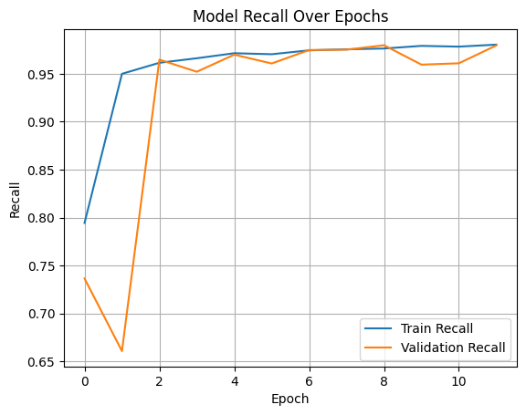

```python
train_vs_valid_curves(history_2)
```

### **Evaluating the model**

```python
#Make predictions on the test set using the second model.
y_pred_2 = model_2.predict(X_test_norm, verbose=1)
#Convert the probabilities into class labels
y_pred_classes_2 = np.argmax(y_pred_2, axis = 1)
y_true_classes = np.argmax(y_test_encoded, axis=1)
```

```
82/82 ━━━━━━━━━━━━━━━━━━━━ 2s 17ms/step
```

#### **Observations and insights:**

- The training recall shows a significant increase in the early epochs. The validation recall also shows a quick drop and then increase.
- The validation recall appears to plateau relatively early in the training process, likely around epoch 2 or 3. This suggests that after this point, the model's ability to generalize and correctly identify positive instances in unseen data is no longer significantly improving.
- However the training recall continues to show a slight upward trend, even after the validation recall has plateaued. This may be an indication of the model starting to overfit the training data. While it keeps learning the specifics of the training set, this learning isn't necessarily translating to better performance on new, unseen data (as reflected by the plateauing validation recall).

**Generate the classification report and confusion matrix**

```python
# Generate classification report (includes precision, recall, F1)
print(classification_report(
    y_true_classes, y_pred_classes_2,
    target_names=['Uninfected', 'Parasitized']
))
```

```
              precision    recall  f1-score   support

  Uninfected       0.99      0.99      0.99      1299
 Parasitized       0.99      0.99      0.99      1300

    accuracy                           0.99      2599
   macro avg       0.99      0.99      0.99      2599
weighted avg       0.99      0.99      0.99      2599
```

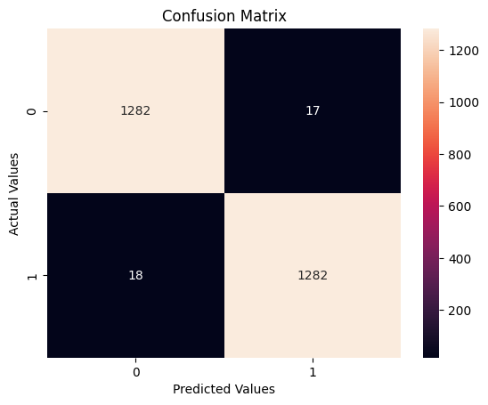

```python
#Ploting the heatmap from the confusion matrix
confus_matrix(y_test, y_pred_classes_2)
```

Observations:

- The parasitized recall value is hihg as the previous model. The only difference is the batch normalization.
- Reasons for worst performance can be Over-regulization: Dropout also regularization: underfitting
- Recall is the most important metric, because identifying a sick cell as healthy, has hugely negative impact on the person's life. Therefore second model is the best so far.

### **Think About It :**

- Can we improve the model with Image Data Augmentation?
- References to image data augmentation can be seen below:
  - [Image Augmentation for Computer Vision](https://www.mygreatlearning.com/blog/understanding-data-augmentation/)
  - [How to Configure Image Data Augmentation in Keras?](https://machinelearningmastery.com/how-to-configure-image-data-augmentation-when-training-deep-learning-neural-networks/)

### **Model 3 with Data Augmentation**

```python
#Clearing previous model's history from the Keras backend
from tensorflow.keras import backend
backend.clear_session()

#Fixing the seed for random number generators so that we can ensure we receive the same output everytime
np.random.seed(42)
import random
random.seed(42)
tf.random.set_seed(42)
```

### **Use image data generator**

```python
# For training data: include augmentations
train_datagen = ImageDataGenerator(
    rescale=1./255,
    rotation_range=15,
    width_shift_range=0.1,
    height_shift_range=0.1,
    shear_range=0.1,
    zoom_range=0.1,
    horizontal_flip=True,
    fill_mode='nearest'
)

## For validation/test: only rescaling
val_datagen = ImageDataGenerator(rescale=1./255)
```

```python
train_generator = train_datagen.flow(X_train, y_train_encoded, batch_size=32)   #combining data + labels + augmentations
val_generator = val_datagen.flow(X_train,y_train_encoded, batch_size=32)
```

### **Think About It :**

- Check if the performance of the model can be improved by changing different parameters in the ImageDataGenerator.

#### **Visualizing Augmented images**

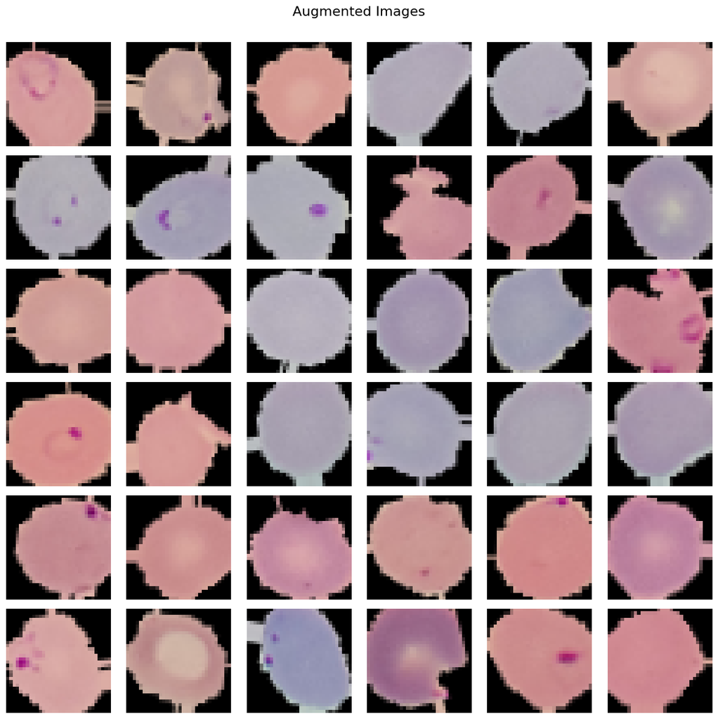

```python
images, labels = next(train_generator)  # This iterates a batch of 32 images

# If batch_size < 36, grab another batch to make up 36
while images.shape[0] < 36:
    new_images, new_labels = next(train_generator)
    images = np.concatenate([images, new_images], axis=0)
    labels = np.concatenate([labels, new_labels], axis=0)

# Set up subplots
fig, axes = plt.subplots(6, 6, figsize=(12, 12))
fig.suptitle('Augmented Images', fontsize=16)
axes = axes.flatten()

# Plot 36 images
for i in range(36):
    image = images[i]

    # If image is in [0, 1], convert to [0, 255] for display
    if image.max() <= 1.0:
        image = (image * 255).astype(np.uint8)

    axes[i].imshow(image.astype(np.uint8))
    axes[i].axis('off')

plt.tight_layout()
plt.subplots_adjust(top=0.93)
plt.show()
```

#### **Observations and insights:**

- The augmented images seem very similar to actual data. Shapes are similar. Colours distribution is also similar, having mainly one colour, and some of the cells have the parasite spots on them.

### **Building the Model**

```python
model_3 = cnn_model_1()
```

**Using Callbacks**

```python
# Stop training if val_loss doesn't improve for 3 epochs
early_stop = EarlyStopping(monitor='val_loss', patience=3, restore_best_weights=True)

# Save the best model only
checkpoint = ModelCheckpoint('best_model.h5', monitor='val_loss', save_best_only=True)
```

**Fit and Train the model**

```python
# Fit the model on the training data with a validation split of 0.2, batch size = 32, verbose = 1, and epochs = 20
# Store the model building history to use later for visualization
history_3=model_3.fit(

    train_generator,
    epochs = 20,
    validation_data=val_generator,
    callbacks=[early_stop, checkpoint],
    batch_size = 32,
    verbose = 1

    )
```

```
781/781 ━━━━━━━━━━━━━━━━━━━━ 0s 66ms/step - accuracy: 0.6866 - loss: 0.5437 - precision: 0.6866 - recall: 0.6866
```

```
WARNING:absl:You are saving your model as an HDF5 file via `model.save()` or `keras.saving.save_model(model)`. This file format is considered legacy. We recommend using instead the native Keras format, e.g. `model.save('my_model.keras')` or `keras.saving.save_model(model, 'my_model.keras')`.
```

```
781/781 ━━━━━━━━━━━━━━━━━━━━ 66s 82ms/step - accuracy: 0.6868 - loss: 0.5434 - precision: 0.6868 - recall: 0.6868 - val_accuracy: 0.9736 - val_loss: 0.0766 - val_precision: 0.9736 - val_recall: 0.9736
781/781 ━━━━━━━━━━━━━━━━━━━━ 0s 64ms/step - accuracy: 0.9603 - loss: 0.1194 - precision: 0.9603 - recall: 0.9603
```

```
WARNING:absl:You are saving your model as an HDF5 file via `model.save()` or `keras.saving.save_model(model)`. This file format is considered legacy. We recommend using instead the native Keras format, e.g. `model.save('my_model.keras')` or `keras.saving.save_model(model, 'my_model.keras')`.
```

```
781/781 ━━━━━━━━━━━━━━━━━━━━ 63s 80ms/step - accuracy: 0.9603 - loss: 0.1194 - precision: 0.9603 - recall: 0.9603 - val_accuracy: 0.9777 - val_loss: 0.0680 - val_precision: 0.9777 - val_recall: 0.9777
781/781 ━━━━━━━━━━━━━━━━━━━━ 63s 80ms/step - accuracy: 0.9677 - loss: 0.0991 - precision: 0.9677 - recall: 0.9677 - val_accuracy: 0.9796 - val_loss: 0.0712 - val_precision: 0.9796 - val_recall: 0.9796
781/781 ━━━━━━━━━━━━━━━━━━━━ 0s 65ms/step - accuracy: 0.9706 - loss: 0.0896 - precision: 0.9706 - recall: 0.9706
```

```
WARNING:absl:You are saving your model as an HDF5 file via `model.save()` or `keras.saving.save_model(model)`. This file format is considered legacy. We recommend using instead the native Keras format, e.g. `model.save('my_model.keras')` or `keras.saving.save_model(model, 'my_model.keras')`.
```

```
781/781 ━━━━━━━━━━━━━━━━━━━━ 83s 82ms/step - accuracy: 0.9706 - loss: 0.0896 - precision: 0.9706 - recall: 0.9706 - val_accuracy: 0.9813 - val_loss: 0.0564 - val_precision: 0.9813 - val_recall: 0.9813
781/781 ━━━━━━━━━━━━━━━━━━━━ 81s 81ms/step - accuracy: 0.9724 - loss: 0.0851 - precision: 0.9724 - recall: 0.9724 - val_accuracy: 0.9813 - val_loss: 0.0567 - val_precision: 0.9813 - val_recall: 0.9813
781/781 ━━━━━━━━━━━━━━━━━━━━ 0s 65ms/step - accuracy: 0.9685 - loss: 0.0918 - precision: 0.9685 - recall: 0.9685
```

```
WARNING:absl:You are saving your model as an HDF5 file via `model.save()` or `keras.saving.save_model(model)`. This file format is considered legacy. We recommend using instead the native Keras format, e.g. `model.save('my_model.keras')` or `keras.saving.save_model(model, 'my_model.keras')`.
```

```
781/781 ━━━━━━━━━━━━━━━━━━━━ 63s 81ms/step - accuracy: 0.9685 - loss: 0.0917 - precision: 0.9685 - recall: 0.9685 - val_accuracy: 0.9814 - val_loss: 0.0561 - val_precision: 0.9814 - val_recall: 0.9814
781/781 ━━━━━━━━━━━━━━━━━━━━ 63s 81ms/step - accuracy: 0.9755 - loss: 0.0741 - precision: 0.9755 - recall: 0.9755 - val_accuracy: 0.9768 - val_loss: 0.0707 - val_precision: 0.9768 - val_recall: 0.9768
781/781 ━━━━━━━━━━━━━━━━━━━━ 72s 92ms/step - accuracy: 0.9738 - loss: 0.0768 - precision: 0.9738 - recall: 0.9738 - val_accuracy: 0.9803 - val_loss: 0.0586 - val_precision: 0.9803 - val_recall: 0.9803
781/781 ━━━━━━━━━━━━━━━━━━━━ 0s 68ms/step - accuracy: 0.9734 - loss: 0.0735 - precision: 0.9734 - recall: 0.9734
```

```
WARNING:absl:You are saving your model as an HDF5 file via `model.save()` or `keras.saving.save_model(model)`. This file format is considered legacy. We recommend using instead the native Keras format, e.g. `model.save('my_model.keras')` or `keras.saving.save_model(model, 'my_model.keras')`.
```

```
781/781 ━━━━━━━━━━━━━━━━━━━━ 65s 84ms/step - accuracy: 0.9734 - loss: 0.0735 - precision: 0.9734 - recall: 0.9734 - val_accuracy: 0.9817 - val_loss: 0.0533 - val_precision: 0.9817 - val_recall: 0.9817
781/781 ━━━━━━━━━━━━━━━━━━━━ 64s 82ms/step - accuracy: 0.9731 - loss: 0.0787 - precision: 0.9731 - recall: 0.9731 - val_accuracy: 0.9795 - val_loss: 0.0569 - val_precision: 0.9795 - val_recall: 0.9795
781/781 ━━━━━━━━━━━━━━━━━━━━ 64s 82ms/step - accuracy: 0.9732 - loss: 0.0796 - precision: 0.9732 - recall: 0.9732 - val_accuracy: 0.9786 - val_loss: 0.0610 - val_precision: 0.9786 - val_recall: 0.9786
781/781 ━━━━━━━━━━━━━━━━━━━━ 0s 67ms/step - accuracy: 0.9753 - loss: 0.0745 - precision: 0.9753 - recall: 0.9753
```

```
WARNING:absl:You are saving your model as an HDF5 file via `model.save()` or `keras.saving.save_model(model)`. This file format is considered legacy. We recommend using instead the native Keras format, e.g. `model.save('my_model.keras')` or `keras.saving.save_model(model, 'my_model.keras')`.
```

```
781/781 ━━━━━━━━━━━━━━━━━━━━ 65s 83ms/step - accuracy: 0.9753 - loss: 0.0745 - precision: 0.9753 - recall: 0.9753 - val_accuracy: 0.9812 - val_loss: 0.0517 - val_precision: 0.9812 - val_recall: 0.9812
781/781 ━━━━━━━━━━━━━━━━━━━━ 64s 82ms/step - accuracy: 0.9753 - loss: 0.0697 - precision: 0.9753 - recall: 0.9753 - val_accuracy: 0.9794 - val_loss: 0.0571 - val_precision: 0.9794 - val_recall: 0.9794
781/781 ━━━━━━━━━━━━━━━━━━━━ 64s 82ms/step - accuracy: 0.9758 - loss: 0.0743 - precision: 0.9758 - recall: 0.9758 - val_accuracy: 0.9809 - val_loss: 0.0538 - val_precision: 0.9809 - val_recall: 0.9809
781/781 ━━━━━━━━━━━━━━━━━━━━ 82s 82ms/step - accuracy: 0.9754 - loss: 0.0748 - precision: 0.9754 - recall: 0.9754 - val_accuracy: 0.9813 - val_loss: 0.0541 - val_precision: 0.9813 - val_recall: 0.9813
```

### **Save the history object**

```python
with open('/content/drive/MyDrive/Great Learning x MIT/Deep Learning/Case Studies/Project - Malaria Detection/history_3.pkl', 'wb') as file:
    pickle.dump(history_3.history, file)
```

### **Load the history object**

```python
with open('/content/drive/MyDrive/Great Learning x MIT/Deep Learning/Case Studies/Project - Malaria Detection/history_3.pkl', 'rb') as file:
    loaded_history = pickle.load(file)
```

### **Evaluating the model**

**Plot the train and validation accuracy**

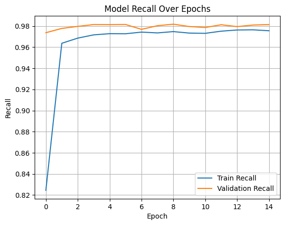

```python
train_vs_valid_curves(history_3)
```

**Plotting the classification report and confusion matrix**

```python
#Make predictions on the test set using the second model.
y_pred_3 = model_3.predict(X_test_norm, verbose=1)
#Convert the probabilities into class labels
y_pred_classes_3 = np.argmax(y_pred_3, axis = 1)
y_true_classes = np.argmax(y_test_encoded, axis=1)
```

```
82/82 ━━━━━━━━━━━━━━━━━━━━ 1s 16ms/step
```

```python
# Generate classification report (includes precision, recall, F1)
print(classification_report(
    y_true_classes, y_pred_classes_3,
    target_names=['Uninfected', 'Parasitized']
))
```

```
              precision    recall  f1-score   support

  Uninfected       0.99      0.99      0.99      1299
 Parasitized       0.99      0.99      0.99      1300

    accuracy                           0.99      2599
   macro avg       0.99      0.99      0.99      2599
weighted avg       0.99      0.99      0.99      2599
```

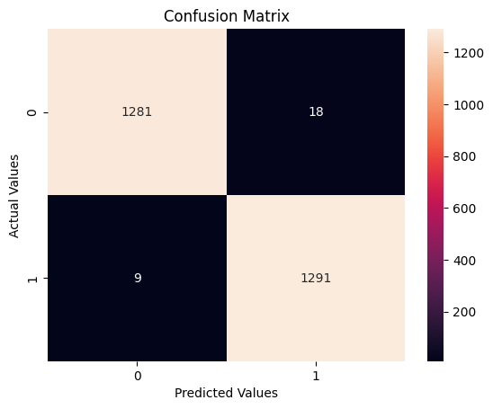

```python
#Ploting the heatmap from the confusion matrix
confus_matrix(y_test, y_pred_classes_3)
```

** Observations:

- Recall for "Parasitized": 0.99. This is precisely what we want in a diagnostic setting where we need to catch as many true positive cases as possible to ensure they receive treatment. However, this molde takes a lot more time to run, so more expensive computationaly.

**Now, let us try to use a pretrained model like VGG16 and check how it performs on our data.**

### **Pre-trained model (VGG16)**

- Import VGG16 network upto any layer you choose
- Add Fully Connected Layers on top of it

```python
from tensorflow.keras.applications import VGG16
```

### Building the model

```python
# Load VGG16 without the top (classification) layers
base_model = VGG16(weights='imagenet', include_top=False, input_shape=(32, 32, 3))

# Pick the 'block2_pool' layer to stop at
output_layer = base_model.get_layer('block2_pool').output

# Create a new model that ends at 'block2_pool'
truncated_vgg = Model(inputs=base_model.input, outputs=output_layer)
```

```
Downloading data from https://storage.googleapis.com/tensorflow/keras-applications/vgg16/vgg16_weights_tf_dim_ordering_tf_kernels_notop.h5
58889256/58889256 ━━━━━━━━━━━━━━━━━━━━ 1s 0us/step
```

```python
# Build a new model with truncated VGG16 (up to 'block2_pool')
model_4 = Sequential()

# Add the truncated VGG16 part (up to 'block2_pool')
model_4.add(truncated_vgg)

# Flatten the output of the convolutional layers (14x14x128 in this case)
model_4.add(Flatten())

# Add fully connected (dense) layers
model_4.add(Dense(1024, activation='relu'))  # Example: 1024 units
model_4.add(Dense(512, activation='relu'))   # Example: 512 units
model_4.add(Dense(2, activation='softmax'))  # Output layer (for 10 classes)
```

### **Compiling the model**

```python
# Compile the model for binary classification
model_4.compile(optimizer=Adam(learning_rate=0.001),
              loss='categorical_crossentropy',
              metrics=['accuracy', Precision(name='precision'), Recall(name='recall')])
```

```python
# freeze the convolutional layers (up to block2_pool)
for layer in model_4.layers[0].layers:  # model.layers[0] refers to the truncated VGG16 part
    layer.trainable = False
```

**using callbacks**

```python
# Stop training if val_loss doesn't improve for 3 epochs
early_stop = EarlyStopping(monitor='val_loss', patience=3, restore_best_weights=True)

# Save the best model only
checkpoint = ModelCheckpoint('best_model.h5', monitor='val_loss', save_best_only=True)
```

**Fit and Train the model**

```python
# Fit the model on the training data with a validation split of 0.2, batch size = 32, verbose = 1, and epochs = 20
# Store the model building history to use later for visualization
history_4=model_4.fit(

    X_train_norm, y_train_encoded, #Use RGB images because that's what VGG models is trained on.
    epochs = 20,
    validation_split=0.20,
    #callbacks=[early_stop, checkpoint],
    batch_size = 32,
    verbose = 1

    )
```

```
625/625 ━━━━━━━━━━━━━━━━━━━━ 122s 195ms/step - accuracy: 0.9677 - loss: 0.0829 - precision: 0.9677 - recall: 0.9677 - val_accuracy: 0.9047 - val_loss: 0.3349 - val_precision: 0.9047 - val_recall: 0.9047
625/625 ━━━━━━━━━━━━━━━━━━━━ 148s 206ms/step - accuracy: 0.9684 - loss: 0.0839 - precision: 0.9684 - recall: 0.9684 - val_accuracy: 0.9249 - val_loss: 0.3082 - val_precision: 0.9249 - val_recall: 0.9249
625/625 ━━━━━━━━━━━━━━━━━━━━ 136s 196ms/step - accuracy: 0.9690 - loss: 0.0821 - precision: 0.9690 - recall: 0.9690 - val_accuracy: 0.9309 - val_loss: 0.2211 - val_precision: 0.9309 - val_recall: 0.9309
625/625 ━━━━━━━━━━━━━━━━━━━━ 126s 201ms/step - accuracy: 0.9711 - loss: 0.0790 - precision: 0.9711 - recall: 0.9711 - val_accuracy: 0.9199 - val_loss: 0.3354 - val_precision: 0.9199 - val_recall: 0.9199
625/625 ━━━━━━━━━━━━━━━━━━━━ 142s 201ms/step - accuracy: 0.9680 - loss: 0.0872 - precision: 0.9680 - recall: 0.9680 - val_accuracy: 0.9309 - val_loss: 0.2592 - val_precision: 0.9309 - val_recall: 0.9309
625/625 ━━━━━━━━━━━━━━━━━━━━ 144s 204ms/step - accuracy: 0.9685 - loss: 0.0938 - precision: 0.9685 - recall: 0.9685 - val_accuracy: 0.9375 - val_loss: 0.2104 - val_precision: 0.9375 - val_recall: 0.9375
480/625 ━━━━━━━━━━━━━━━━━━━━ 24s 172ms/step - accuracy: 0.9705 - loss: 0.0760 - precision: 0.9705 - recall: 0.9705
```

### **Save the history object**

```python
import pickle
with open('/content/drive/MyDrive/Great Learning x MIT/Deep Learning/Case Studies/Project - Malaria Detection/history_4.pkl', 'wb') as file:
    pickle.dump(history_4.history, file)
```

### **Load the history object**

```python
with open('/content/drive/MyDrive/Great Learning x MIT/Deep Learning/Case Studies/Project - Malaria Detection/history_4.pkl', 'rb') as file:
    loaded_history = pickle.load(file)
```

**Plot the train and validation accuracy**

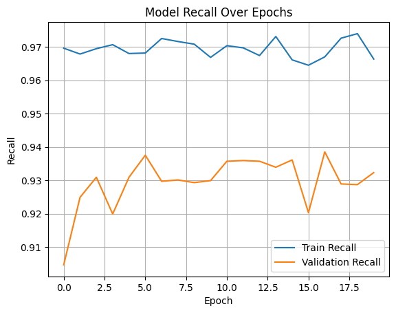

```python
def train_vs_valid_curves(history):
  plt.plot(history.history['recall'], label='Train Recall')
  plt.plot(history.history['val_recall'], label='Validation Recall')
  # plt.plot(history_0.history['precision'])
  # plt.plot(history_0.history['val_precision'])
  plt.title('Model Recall Over Epochs')
  plt.ylabel('Recall')
  plt.xlabel('Epoch')
  plt.legend(loc='lower right')
  plt.grid(True)
  plt.show()

train_vs_valid_curves(history_4)
```

### **Observations and insights: **

- What can be observed from the validation and train curves?

Training data us higher than the validation, there is overfitting.

### **Evaluating the model**

```python
#Make predictions on the test set using the second model.
y_pred_4 = model_4.predict(X_test_norm , verbose=1)
#Convert the probabilities into class labels
y_pred_classes_4 = np.argmax(y_pred_4, axis = 1)
y_true_classes = np.argmax(y_test_encoded, axis=1)
```

```
82/82 ━━━━━━━━━━━━━━━━━━━━ 8s 90ms/step
```

**Plotting the classification report and confusion matrix**

```python
# Generate classification report (includes precision, recall, F1)
print(classification_report(
    y_true_classes, y_pred_classes_4,
    target_names=['Uninfected', 'Parasitized']
))
```

```
              precision    recall  f1-score   support

  Uninfected       0.94      0.89      0.91      1299
 Parasitized       0.89      0.94      0.92      1300

    accuracy                           0.91      2599
   macro avg       0.92      0.91      0.91      2599
weighted avg       0.92      0.91      0.91      2599
```

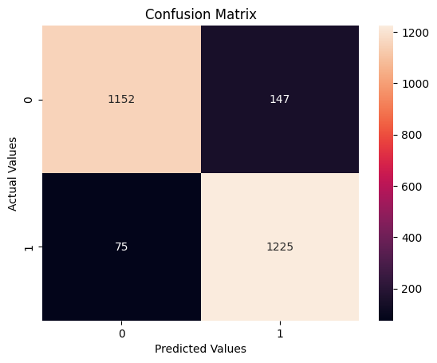

```python
#Ploting the heatmap from the confusion matrix
def confus_matrix(y_true, y_pred):
  cm = confusion_matrix(y_true, y_pred)
  sns.heatmap(cm, annot = True, fmt = 'd')
  plt.title('Confusion Matrix')
  plt.ylabel('Actual Values')
  plt.xlabel('Predicted Values')
  plt.show()

confus_matrix(y_test, y_pred_classes_4)
```

### **Think about it:**

- What observations and insights can be drawn from the confusion matrix and classification report?
- Choose the model with the best accuracy scores from all the above models and save it as a final model.

#### **Observations and Conclusions drawn from the final model:**

- This model shows a moderate performance in classifying "Uninfected" and "Parasitized" cells, with an overall accuracy of 0.91 and recall of 0.91. The model identifies only 94% of all the actual "Parasitized" cells. This means it misses more than the previous models.

**Improvements that can be done:**

- Can the model performance be improved using other pre-trained models or different CNN architecture?
- You can try to build a model using these HSV images and compare them with your other models.

#### **Refined insights**:

- What are the most meaningful insights from the data relevant to the problem?
- In the context of malaria detection, the emphasis is on maximizing recall for the "Parasitized" class. Missing a parasitized cell (false negative) has much more severe consequences than misclassifying an uninfected cell (false positive). False negatives can lead to delayed treatment and increased health risks for the patient.
- Challenges in Detection: The detection of parasitized cells is challenging due to subtle visual differences between parasitized and uninfected cells, variations in cell shapes and colors or the potential for noise and artifacts in the images.
- Different models may exhibit different strengths and weaknesses in detecting parasitized cells. The choice of model often involves balancing the need for high recall with the tolerance for false positives. Models that prioritize recall might be preferred in initial screening, even if they produce more false positives, as these cases can be further investigated with more specific diagnostic tests.

#### **Comparison of various techniques and their relative performance**:

- How do different techniques perform? Which one is performing relatively better? Is there scope to improve the performance further?
  - The ANN model has 65% recall, which is very low. The model is done as a start and confirmed that for image classfications, ANN models are not the sufficient.
  - The CNN model, for model 0,1,2, the recall increased as the model got more layers. The model 1 appears to be the best. The addition of the batch normalization, next to Dropout and LeakReLu layers seem to bring too much regularization. In addition the model 1 achieves same level of accuracy, precision and f1 score, which is 99%, with less complex model.
  - The augmented images with the previous CNN architecture, same level of recall at 99% for parasitized. However it can argued that the additional preprocessing that needs to be done with augmented images is not necessary, as simpler models also provide same level of succesful classifications.
  - The pretrained performs not as good as the prevpius CNN models, as the recall for parasitized cells reamin at 94%.

#### **Proposal for the final solution design**:

- What model do you propose to be adopted? Why is this the best solution to adopt?
  - In conclusion, using different methods, same level of of recall (precision, f1-score, accuracy) can be achieved. The CNN model 1 delivers 99% in all metrics to classify the malaria cells correctly and helps identify sick people. Another positive side of this model is that it is simpler compared to other models that have the same metrics, therefore is it more efficient computationally.